# Customer Churn Machine Learning Project

Krisztian Szavuly

January 14, 2017

## Data Source

Base management is an important discipline for telecommunication companies, more precisely tracking their customers’ churn rates. Identifying and fighting potential churn is key maintaining the level of revenues. The database used for the experiment was part of the KDD 2009 Cup and is now available in the Cortana Intelligence gallery along with a set up experiment. Link: https://gallery.cortanaintelligence.com/Experiment/4dfb7478169f46158eb895014439689e

## Reading and First Look at the Data

Our dataset contains 20468 observations and 29 variables, with 0 NAs.We dropped the Month and Year variables possibly referring to the data recording timeframe of the churn. We removed calling number and customer ID in order to keep the dataset anonymized.

```r
dataset <- read.csv("CATelcoCustomerChurnTrainingSample.csv")
colnames(dataset)
```

```
##  [1] "age"
##  [2] "annualincome"
##  [3] "calldroprate"
##  [4] "callfailurerate"
##  [5] "callingnum"
##  [6] "customerid"
##  [7] "customersuspended"
##  [8] "education"
##  [9] "gender"
## [10] "homeowner"
## [11] "maritalstatus"
## [12] "monthlybilledamount"
## [13] "noadditionallines"
## [14] "numberofcomplaints"
## [15] "numberofmonthunpaid"
## [16] "numdayscontractequipmentplanexpiring"
## [17] "occupation"
## [18] "penaltytoswitch"
## [19] "state"
## [20] "totalminsusedinlastmonth"
## [21] "unpaidbalance"
## [22] "usesinternetservice"
## [23] "usesvoiceservice"
## [24] "percentagecalloutsidenetwork"
## [25] "totalcallduration"
## [26] "avgcallduration"
## [27] "churn"
## [28] "year"
## [29] "month"
```

```r
dataset$year <- NULL
dataset$month <- NULL
dataset$callingnum <- NULL
dataset$customerid <- NULL
sum(is.na(dataset))
```

```
## [1] 0
```

## Analyzing Variables

Before digging deeper into the variables one by one, we can take a quick look at the whole dataset’s summaries. Some of the predictors will be numeric (like age), some boolean (like home owner) and some categorical (like state). We suspect that we have on hand a nicely cleaned dataset, as no NA’s were found.

```r
summary(dataset)
```

```
##       age         annualincome     calldroprate     callfailurerate
##  Min.   :12.00   Min.   :     4   Min.   :0.00000   Min.   :0.00000
##  1st Qu.:28.00   1st Qu.: 61898   1st Qu.:0.01000   1st Qu.:0.01000
##  Median :45.00   Median :123690   Median :0.04000   Median :0.02000
##  Mean   :45.33   Mean   :124447   Mean   :0.03502   Mean   :0.01524
##  3rd Qu.:62.00   3rd Qu.:187065   3rd Qu.:0.06000   3rd Qu.:0.03000
##  Max.   :79.00   Max.   :249987   Max.   :0.07000   Max.   :0.03000
##
##  customersuspended                  education        gender
##  No :  442         Bachelor or equivalent: 6138   Female:10474
##  Yes:20026         High School or below  :10217   Male  : 9994
##                    Master or equivalent  : 3099
##                    PhD or equivalent     : 1014
##
##
##
##  homeowner   maritalstatus   monthlybilledamount noadditionallines
##  No : 4088   Married:10022   Min.   :  0.00      \\N:20468
##  Yes:16380   Single :10446   1st Qu.: 29.00
##                              Median : 60.00
##                              Mean   : 59.63
##                              3rd Qu.: 90.00
##                              Max.   :119.00
##
##  numberofcomplaints numberofmonthunpaid
##  Min.   :0.000      Min.   :0.000
##  1st Qu.:0.000      1st Qu.:1.000
##  Median :2.000      Median :3.000
##  Mean   :1.499      Mean   :3.489
##  3rd Qu.:3.000      3rd Qu.:5.000
##  Max.   :3.000      Max.   :7.000
##
##  numdayscontractequipmentplanexpiring                      occupation
##  Min.   : 0.00                        Non-technology Related Job:6189
##  1st Qu.:24.00                        Others                    :8189
##  Median :49.00                        Technology Related Job    :6090
##  Mean   :49.37
##  3rd Qu.:74.00
##  Max.   :99.00
##
```

[output cut: 9 more lines]

```
##  No :19675           No :18598        Min.   :0.0000
##  Yes:  793           Yes: 1870        1st Qu.:0.2500
##                                       Median :0.5000
##                                       Mean   :0.4965
##                                       3rd Qu.:0.7500
##                                       Max.   :0.9900
##
##  totalcallduration avgcallduration      churn
##  Min.   :    0     Min.   :   0.0   Min.   :0.00000
##  1st Qu.: 2048     1st Qu.: 582.0   1st Qu.:0.00000
##  Median : 3365     Median : 721.0   Median :0.00000
##  Mean   : 3522     Mean   : 721.5   Mean   :0.09102
##  3rd Qu.: 4786     3rd Qu.: 862.0   3rd Qu.:0.00000
##  Max.   :16662     Max.   :1439.0   Max.   :1.00000
##
```

## Predictor: Age

Our first predictor’s observations shows a balanced distribution, with a median of 45 years. Although the youngest member of our dataset is only 12 years old, we decide to keep all observations because of the symmetric distribution.

When regressing age on churn categories (0 for no churn and 1 for churn) we see a negative slope: people of younger age are more likely to churn. Please note that regression tables and plots represent data with an opposite regression.

```r
summary(dataset$age)
```

```
##    Min. 1st Qu.  Median    Mean 3rd Qu.    Max.
##   12.00   28.00   45.00   45.33   62.00   79.00
```

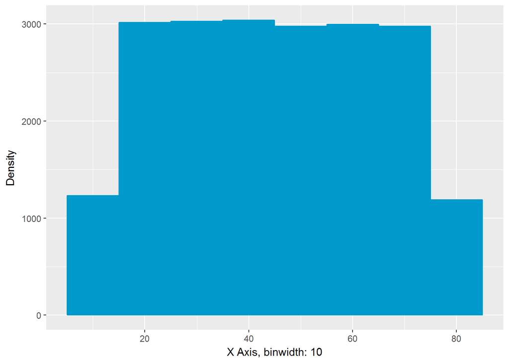

```r
ggplot(dataset, aes(x = age)) +
  geom_histogram(stat = "bin", binwidth = 10, colour = "deepskyblue3", fill = "deepskyblue3") + labs(x = "X Axis, binwidth: 10", y = "Density")
```

```r
reg1 <- lm(churn ~ age, data = dataset)
summary(reg1)
```

```
##
## Call:
## lm(formula = churn ~ age, data = dataset)
##
## Residuals:
##      Min       1Q   Median       3Q      Max
## -0.15828 -0.11994 -0.08161 -0.04529  0.97691
##
## Coefficients:
##               Estimate Std. Error t value Pr(>|t|)
## (Intercept)  0.1824893  0.0050131   36.40   <2e-16 ***
## age         -0.0020177  0.0001015  -19.88   <2e-16 ***
## ---
## Signif. codes:  0 '***' 0.001 '**' 0.01 '*' 0.05 '.' 0.1 ' ' 1
##
## Residual standard error: 0.2849 on 20466 degrees of freedom
## Multiple R-squared:  0.01895,    Adjusted R-squared:  0.0189
## F-statistic: 395.3 on 1 and 20466 DF,  p-value: < 2.2e-16
```

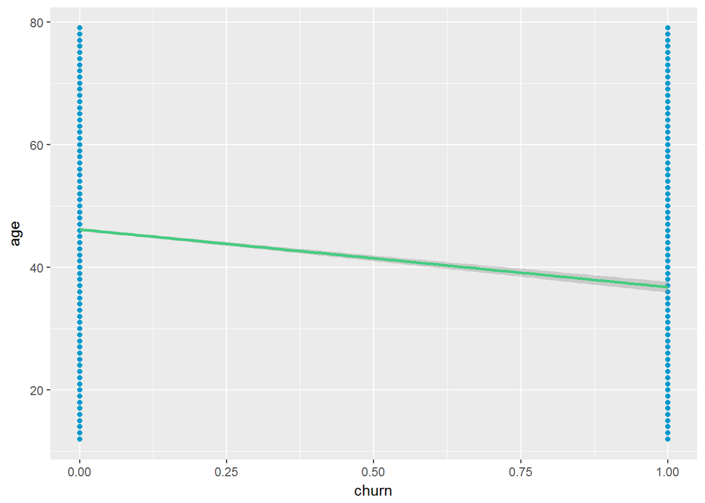

```r
ggplot(data = dataset, aes(x = churn, y = age)) +
  geom_point(size = 1.5, colour = "deepskyblue3") +
  geom_smooth(method = "lm", colour = "seagreen3", se = T)
```

## Predictor: Annual Income

When regressing churn on income we see no correlation between annual income and likelihood to churn.

```r
summary(dataset$annualincome)
```

```
##    Min. 1st Qu.  Median    Mean 3rd Qu.    Max.
##       4   61900  123700  124400  187100  250000
```

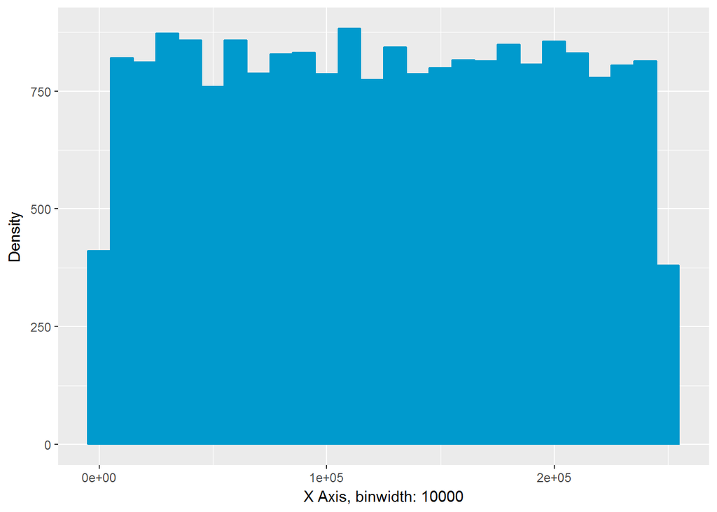

```r
ggplot(dataset, aes(x = annualincome)) +
  geom_histogram(stat = "bin", binwidth = 10000, colour = "deepskyblue3", fill = "deepskyblue3") + labs(x = "X Axis, binwidth: 10000", y = "Density")
```

```r
reg2 <- lm(churn ~ annualincome, data = dataset)
summary(reg2)
```

```
##
## Call:
## lm(formula = churn ~ annualincome, data = dataset)
##
## Residuals:
##      Min       1Q   Median       3Q      Max
## -0.09191 -0.09142 -0.09093 -0.09044  0.90987
##
## Coefficients:
##                Estimate Std. Error t value Pr(>|t|)
## (Intercept)   9.191e-02  4.010e-03  22.923   <2e-16 ***
## annualincome -7.179e-09  2.788e-08  -0.258    0.797
## ---
## Signif. codes:  0 '***' 0.001 '**' 0.01 '*' 0.05 '.' 0.1 ' ' 1
##
## Residual standard error: 0.2877 on 20466 degrees of freedom
## Multiple R-squared:  3.24e-06,   Adjusted R-squared:  -4.562e-05
## F-statistic: 0.06632 on 1 and 20466 DF,  p-value: 0.7968
```

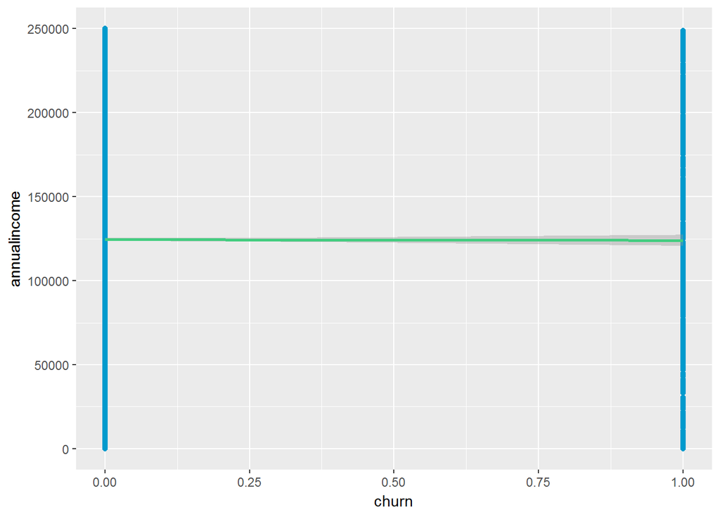

```r
ggplot(data = dataset, aes(x = churn, y = annualincome)) +
  geom_point(size = 1.5, colour = "deepskyblue3") +
  geom_smooth(method = "lm", colour = "seagreen3", se = T)
```

## Predictor: Call Drop Rate

We assume that call drop rate is important predictor of a possible churn, as it is directly connected to the quality of service a customer receives. The median call drop rate is of 0.04, so 4% of the calls being dropped, with a symmetric distribution between no drops and 7% drops.

When regressing churn on call drop rate we see a 0.08 higher churn for those having one unit higher call drops.

```r
summary(dataset$calldroprate)
```

```
##    Min. 1st Qu.  Median    Mean 3rd Qu.    Max.
## 0.00000 0.01000 0.04000 0.03502 0.06000 0.07000
```

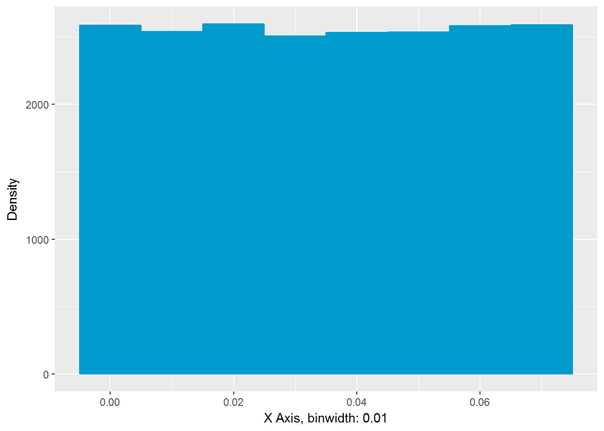

```r
ggplot(dataset, aes(x = calldroprate)) +
  geom_histogram(stat = "bin", binwidth = 0.01, colour = "deepskyblue3", fill = "deepskyblue3") + labs(x = "X Axis, binwidth: 0.01", y = "Density")
```

```r
reg3 <- lm(churn ~ calldroprate, data = dataset)
summary(reg3)
```

```
##
## Call:
## lm(formula = churn ~ calldroprate, data = dataset)
##
## Residuals:
##      Min       1Q   Median       3Q      Max
## -0.09404 -0.09231 -0.09059 -0.08886  0.91201
##
## Coefficients:
##              Estimate Std. Error t value Pr(>|t|)
## (Intercept)  0.087995   0.003663  24.022   <2e-16 ***
## calldroprate 0.086383   0.087433   0.988    0.323
## ---
## Signif. codes:  0 '***' 0.001 '**' 0.01 '*' 0.05 '.' 0.1 ' ' 1
##
## Residual standard error: 0.2876 on 20466 degrees of freedom
## Multiple R-squared:  4.769e-05,  Adjusted R-squared:  -1.167e-06
## F-statistic: 0.9761 on 1 and 20466 DF,  p-value: 0.3232
```

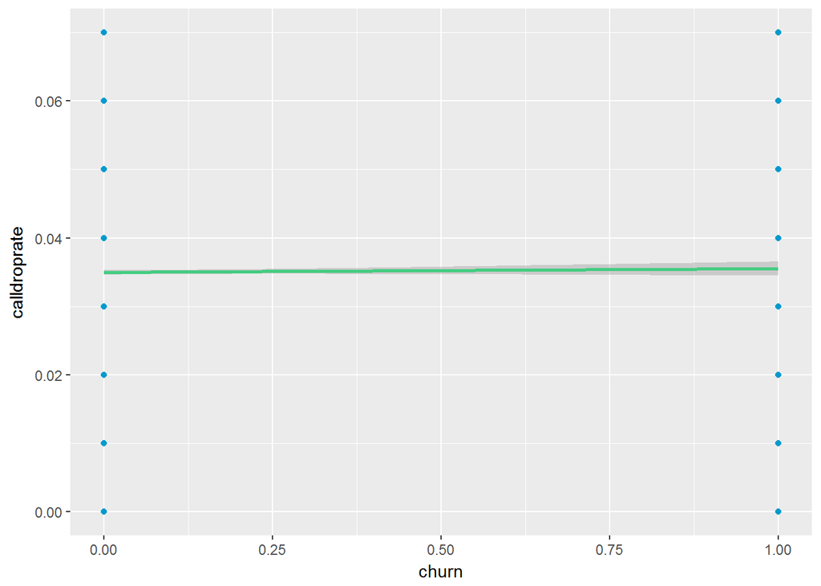

```r
ggplot(data = dataset, aes(x = churn, y = calldroprate)) +
  geom_point(size = 1.5, colour = "deepskyblue3") +
  geom_smooth(method = "lm", colour = "seagreen3", se = T)
```

## Predictor: Call Failure Rate

We assume that call failure rate is important predictor of a possible churn, as it is directly connected to the quality of service a customer receives. The median call failure rate is of 0.02, so 2% of the calls fail, with an almost symmetric distribution between no failure and 3% failures

When regressing call failure rate on churn we see a 0.09 higher churn for those having one unit higher call drops, although with no statistical significance.

```r
summary(dataset$callfailurerate)
```

```
##    Min. 1st Qu.  Median    Mean 3rd Qu.    Max.
## 0.00000 0.01000 0.02000 0.01524 0.03000 0.03000
```

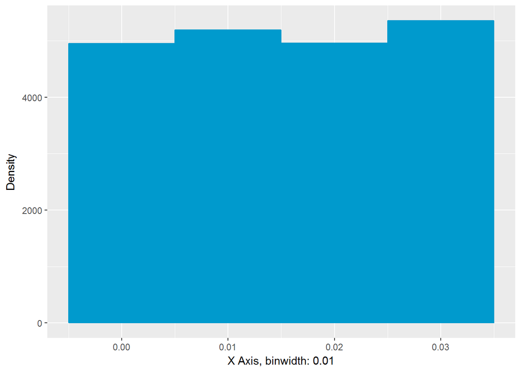

```r
ggplot(dataset, aes(x = callfailurerate)) +
  geom_histogram(stat = "bin", binwidth = 0.01, colour = "deepskyblue3", fill = "deepskyblue3") + labs(x = "X Axis, binwidth: 0.01", y = "Density")
```

```r
reg4 <- lm(churn ~ callfailurerate, data = dataset)
summary(reg4)
```

```
##
## Call:
## lm(formula = churn ~ callfailurerate, data = dataset)
##
## Residuals:
##      Min       1Q   Median       3Q      Max
## -0.09234 -0.09145 -0.09055 -0.08966  0.91034
##
## Coefficients:
##                 Estimate Std. Error t value Pr(>|t|)
## (Intercept)     0.089659   0.003393  26.428   <2e-16 ***
## callfailurerate 0.089344   0.179315   0.498    0.618
## ---
## Signif. codes:  0 '***' 0.001 '**' 0.01 '*' 0.05 '.' 0.1 ' ' 1
##
## Residual standard error: 0.2877 on 20466 degrees of freedom
## Multiple R-squared:  1.213e-05,  Adjusted R-squared:  -3.673e-05
## F-statistic: 0.2483 on 1 and 20466 DF,  p-value: 0.6183
```

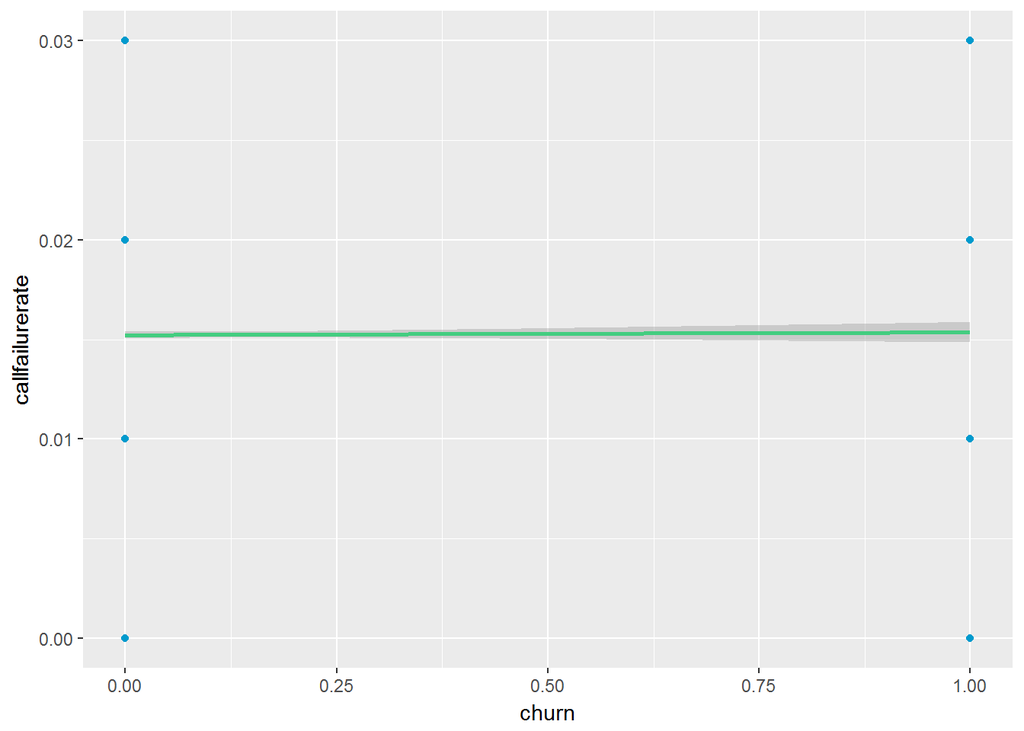

```r
ggplot(data = dataset, aes(x = churn, y = callfailurerate)) +
  geom_point(size = 1.5, colour = "deepskyblue3") +
  geom_smooth(method = "lm", colour = "seagreen3", se = T)
```

## Predictor: Customer Suspension

Due to the high number of suspensions (20026 observations) compared to the non-suspended customers, we suspect CRM systems to technically suspend customers in a lot of cases, which might not always be perceived as suspension by the clients. Suspension will be removed from the predictors.

```r
summary(dataset$customersuspended)
```

```
##    No   Yes
##   442 20026
```

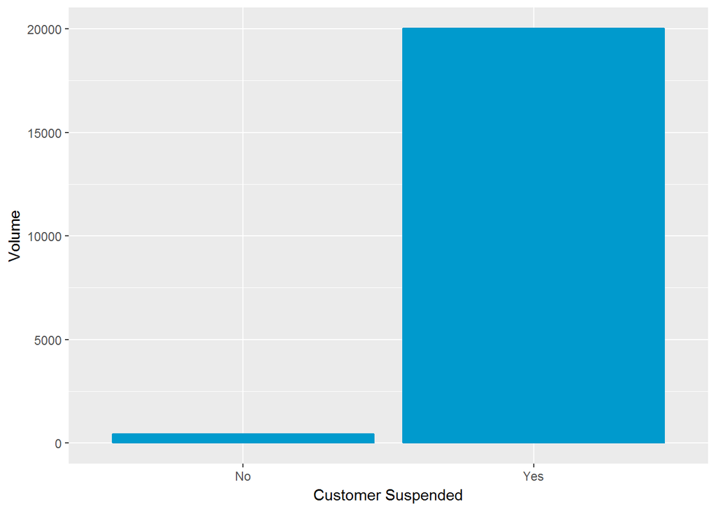

```r
ggplot(dataset, aes(customersuspended, ..count..)) +
  geom_bar(colour = "deepskyblue3", fill = "deepskyblue3") + labs(x = "Customer Suspended", y = "Volume")
```

```r
reg5 <- lm(churn ~ customersuspended, data = dataset)
summary(reg5)
```

```
##
## Call:
## lm(formula = churn ~ customersuspended, data = dataset)
##
## Residuals:
##      Min       1Q   Median       3Q      Max
## -0.10407 -0.09073 -0.09073 -0.09073  0.90927
##
## Coefficients:
##                      Estimate Std. Error t value Pr(>|t|)
## (Intercept)           0.10407    0.01368   7.607 2.94e-14 ***
## customersuspendedYes -0.01334    0.01383  -0.964    0.335
## ---
## Signif. codes:  0 '***' 0.001 '**' 0.01 '*' 0.05 '.' 0.1 ' ' 1
##
## Residual standard error: 0.2876 on 20466 degrees of freedom
## Multiple R-squared:  4.545e-05,  Adjusted R-squared:  -3.412e-06
## F-statistic: 0.9302 on 1 and 20466 DF,  p-value: 0.3348
```

## Predictor: Education

```r
summary(dataset$education)
```

```
## Bachelor or equivalent   High School or below   Master or equivalent
##                   6138                  10217                   3099
##      PhD or equivalent
##                   1014
```

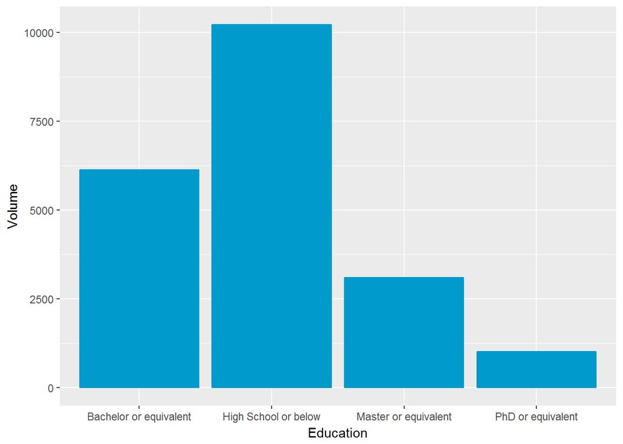

```r
ggplot(dataset, aes(education, ..count..)) +
  geom_bar(colour = "deepskyblue3", fill = "deepskyblue3") + labs(x = "Education", y = "Volume")
```

```r
reg6 <- lm(churn ~ education, data = dataset)
summary(reg6)
```

```
##
## Call:
## lm(formula = churn ~ education, data = dataset)
##
## Residuals:
##      Min       1Q   Median       3Q      Max
## -0.10256 -0.09759 -0.09142 -0.09142  0.92707
##
## Coefficients:
##                                Estimate Std. Error t value Pr(>|t|)
## (Intercept)                    0.097589   0.003670  26.589  < 2e-16 ***
## educationHigh School or below -0.006173   0.004644  -1.329    0.184
## educationMaster or equivalent -0.024662   0.006336  -3.892 9.97e-05 ***
## educationPhD or equivalent     0.004975   0.009747   0.510    0.610
## ---
## Signif. codes:  0 '***' 0.001 '**' 0.01 '*' 0.05 '.' 0.1 ' ' 1
##
## Residual standard error: 0.2875 on 20464 degrees of freedom
## Multiple R-squared:  0.0008362,  Adjusted R-squared:  0.0006898
## F-statistic: 5.709 on 3 and 20464 DF,  p-value: 0.0006677
```

## Predictor: Gender

```r
summary(dataset$gender)
```

```
## Female   Male
##  10474   9994
```

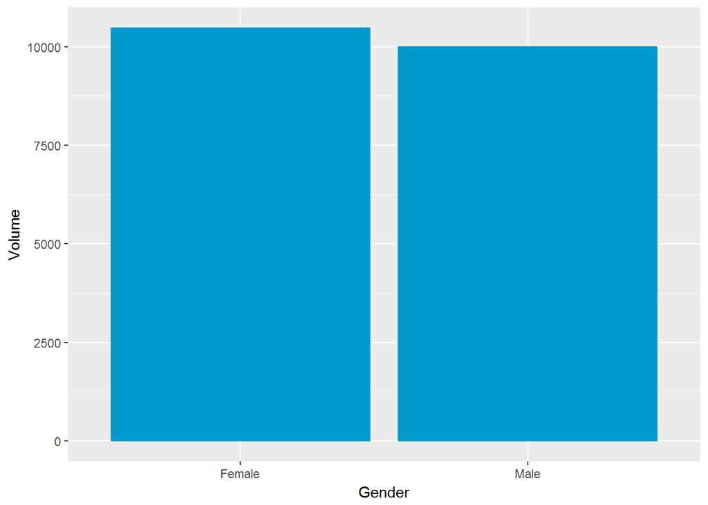

```r
ggplot(dataset, aes(gender, ..count..)) +
  geom_bar(colour = "deepskyblue3", fill = "deepskyblue3") + labs(x = "Gender", y = "Volume")
```

```r
reg7 <- lm(churn ~ gender, data = dataset)
summary(reg7)
```

```
##
## Call:
## lm(formula = churn ~ gender, data = dataset)
##
## Residuals:
##      Min       1Q   Median       3Q      Max
## -0.09261 -0.09261 -0.08935 -0.08935  0.91065
##
## Coefficients:
##              Estimate Std. Error t value Pr(>|t|)
## (Intercept)  0.092610   0.002811   32.95   <2e-16 ***
## genderMale  -0.003257   0.004022   -0.81    0.418
## ---
## Signif. codes:  0 '***' 0.001 '**' 0.01 '*' 0.05 '.' 0.1 ' ' 1
##
## Residual standard error: 0.2876 on 20466 degrees of freedom
## Multiple R-squared:  3.203e-05,  Adjusted R-squared:  -1.683e-05
## F-statistic: 0.6555 on 1 and 20466 DF,  p-value: 0.4181
```

## Predictor: Home Owner

```r
summary(dataset$homeowner)
```

```
##    No   Yes
##  4088 16380
```

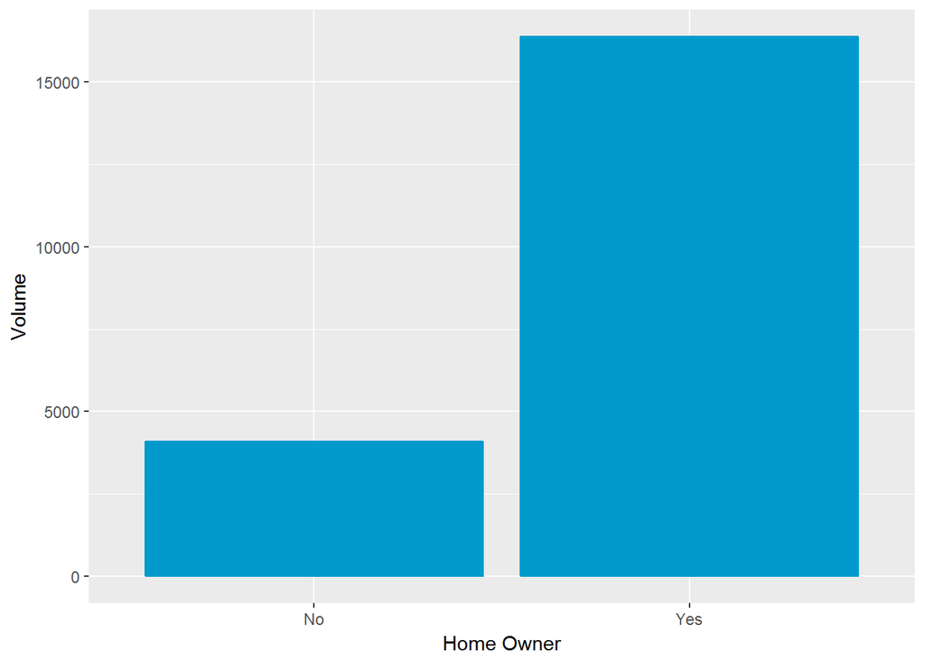

```r
ggplot(dataset, aes(homeowner, ..count..)) +
  geom_bar(colour = "deepskyblue3", fill = "deepskyblue3") + labs(x = "Home Owner", y = "Volume")
```

```r
reg8 <- lm(churn ~ homeowner, data = dataset)
summary(reg8)
```

```
##
## Call:
## lm(formula = churn ~ homeowner, data = dataset)
##
## Residuals:
##      Min       1Q   Median       3Q      Max
## -0.09491 -0.09005 -0.09005 -0.09005  0.90995
##
## Coefficients:
##               Estimate Std. Error t value Pr(>|t|)
## (Intercept)   0.094912   0.004499  21.097   <2e-16 ***
## homeownerYes -0.004863   0.005029  -0.967    0.334
## ---
## Signif. codes:  0 '***' 0.001 '**' 0.01 '*' 0.05 '.' 0.1 ' ' 1
##
## Residual standard error: 0.2876 on 20466 degrees of freedom
## Multiple R-squared:  4.569e-05,  Adjusted R-squared:  -3.171e-06
## F-statistic: 0.9351 on 1 and 20466 DF,  p-value: 0.3336
```

## Predictor: Marital Status

```r
summary(dataset$maritalstatus)
```

```
## Married  Single
##   10022   10446
```

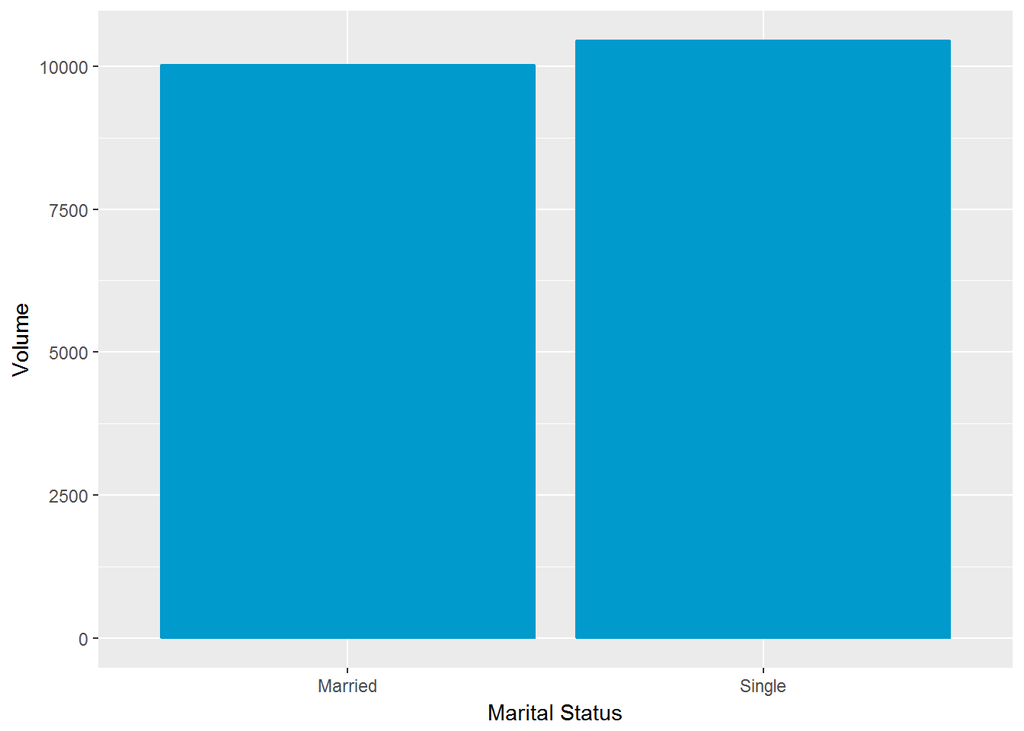

```r
ggplot(dataset, aes(maritalstatus, ..count..)) +
  geom_bar(colour = "deepskyblue3", fill = "deepskyblue3") + labs(x = "Marital Status", y = "Volume")
```

```r
reg9 <- lm(churn ~ maritalstatus, data = dataset)
summary(reg9)
```

```
##
## Call:
## lm(formula = churn ~ maritalstatus, data = dataset)
##
## Residuals:
##      Min       1Q   Median       3Q      Max
## -0.09640 -0.09640 -0.08541 -0.08541  0.91459
##
## Coefficients:
##                     Estimate Std. Error t value Pr(>|t|)
## (Intercept)         0.085412   0.002873  29.731  < 2e-16 ***
## maritalstatusSingle 0.010988   0.004021   2.733  0.00629 **
## ---
## Signif. codes:  0 '***' 0.001 '**' 0.01 '*' 0.05 '.' 0.1 ' ' 1
##
## Residual standard error: 0.2876 on 20466 degrees of freedom
## Multiple R-squared:  0.0003647,  Adjusted R-squared:  0.0003159
## F-statistic: 7.467 on 1 and 20466 DF,  p-value: 0.006291
```

## Predictor: Monthly Billed Amount

Monthly billed amount is a very important factor in a telecommunications services. In our dataset, there’s a very symmetric distribution with a median of 60 USD. In a more precise description of the dataset:

- minimum is 0 USD
- 1st quartile is 29 USD
- 3rd quartile is 90 USD (50% of the distribution is between 29 and 90 USD)
- maximum is 119 USD

```r
summary(dataset$monthlybilledamount)
```

```
##    Min. 1st Qu.  Median    Mean 3rd Qu.    Max.
##    0.00   29.00   60.00   59.63   90.00  119.00
```

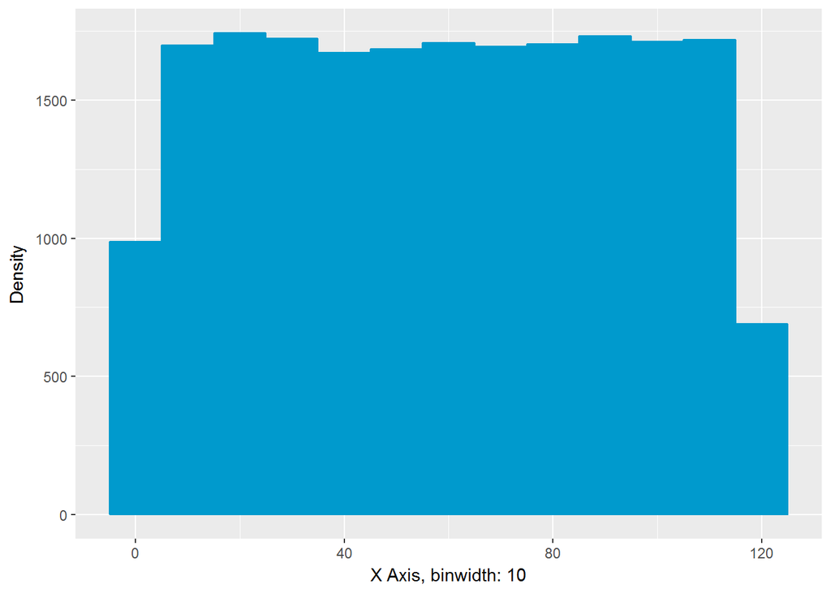

```r
ggplot(dataset, aes(x = monthlybilledamount)) +
  geom_histogram(stat = "bin", binwidth = 10, colour = "deepskyblue3", fill = "deepskyblue3") + labs(x = "X Axis, binwidth: 10", y = "Density")
```

```r
reg10 <- lm(churn ~ monthlybilledamount, data = dataset)
summary(reg10)
```

```
##
## Call:
## lm(formula = churn ~ monthlybilledamount, data = dataset)
##
## Residuals:
##      Min       1Q   Median       3Q      Max
## -0.09587 -0.09326 -0.09056 -0.08778  0.91385
##
## Coefficients:
##                      Estimate Std. Error t value Pr(>|t|)
## (Intercept)         8.615e-02  4.002e-03  21.529   <2e-16 ***
## monthlybilledamount 8.170e-05  5.802e-05   1.408    0.159
## ---
## Signif. codes:  0 '***' 0.001 '**' 0.01 '*' 0.05 '.' 0.1 ' ' 1
##
## Residual standard error: 0.2876 on 20466 degrees of freedom
## Multiple R-squared:  9.686e-05,  Adjusted R-squared:  4.801e-05
## F-statistic: 1.983 on 1 and 20466 DF,  p-value: 0.1591
```

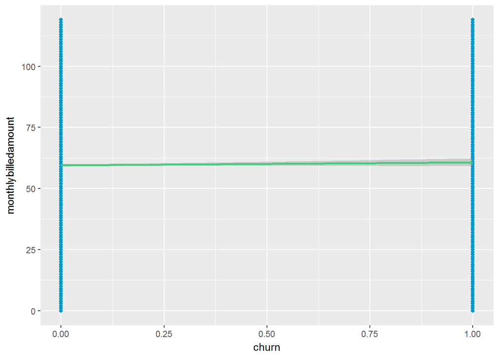

```r
ggplot(data = dataset, aes(x = churn, y = monthlybilledamount)) +
  geom_point(size = 1.5, colour = "deepskyblue3") +
  geom_smooth(method = "lm", colour = "seagreen3", se = T)
```

## Predictor: No Additional Lines

As none of the observed customers have additional lines, this variable will be removed from the predictors.

```r
summary(dataset$noadditionallines)
```

```
##   \\N
## 20468
```

## Predictor: Number of Complaints

```r
summary(dataset$numberofcomplaints)
```

```
##    Min. 1st Qu.  Median    Mean 3rd Qu.    Max.
##   0.000   0.000   2.000   1.499   3.000   3.000
```

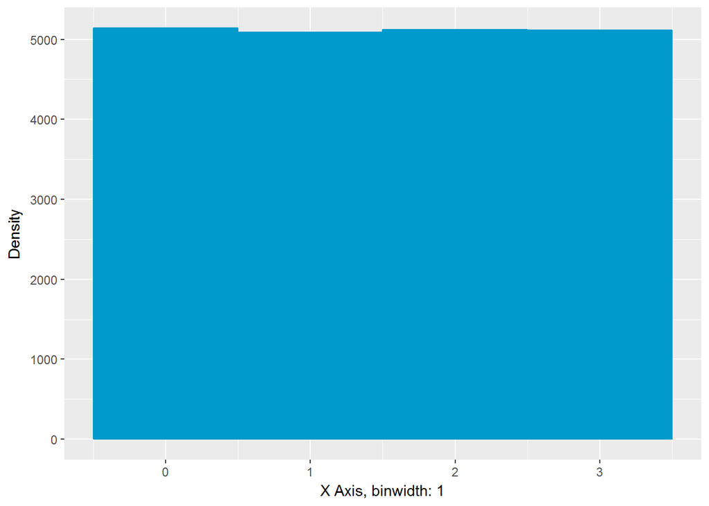

```r
ggplot(dataset, aes(x = numberofcomplaints)) +
  geom_histogram(stat = "bin", binwidth = 1, colour = "deepskyblue3", fill = "deepskyblue3") + labs(x = "X Axis, binwidth: 1", y = "Density")
```

```r
reg11 <- lm(churn ~ numberofcomplaints, data = dataset)
summary(reg11)
```

```
##
## Call:
## lm(formula = churn ~ numberofcomplaints, data = dataset)
##
## Residuals:
##      Min       1Q   Median       3Q      Max
## -0.11210 -0.09805 -0.08401 -0.06996  0.93004
##
## Coefficients:
##                    Estimate Std. Error t value Pr(>|t|)
## (Intercept)        0.069964   0.003356  20.847  < 2e-16 ***
## numberofcomplaints 0.014045   0.001794   7.829 5.14e-15 ***
## ---
## Signif. codes:  0 '***' 0.001 '**' 0.01 '*' 0.05 '.' 0.1 ' ' 1
##
## Residual standard error: 0.2872 on 20466 degrees of freedom
## Multiple R-squared:  0.002986,   Adjusted R-squared:  0.002937
## F-statistic:  61.3 on 1 and 20466 DF,  p-value: 5.142e-15
```

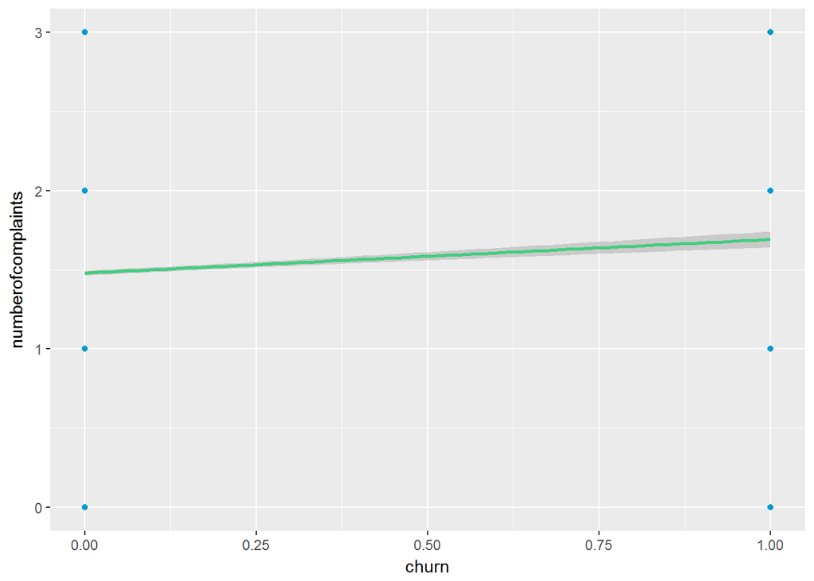

```r
ggplot(data = dataset, aes(x = churn, y = numberofcomplaints)) +
  geom_point(size = 1.5, colour = "deepskyblue3") +
  geom_smooth(method = "lm", colour = "seagreen3", se = T)
```

## Predictor: Number of Month Unpaid

It might be surprising, that number of months unpaid doesn’t show right skewness (making 0 unpaid months in most observations), but it equally distributed from 0 to 7 months. However, there doesn’t seem to be a correlation between number of months unpaid and churn.

```r
summary(dataset$numberofmonthunpaid)
```

```
##    Min. 1st Qu.  Median    Mean 3rd Qu.    Max.
##   0.000   1.000   3.000   3.489   5.000   7.000
```

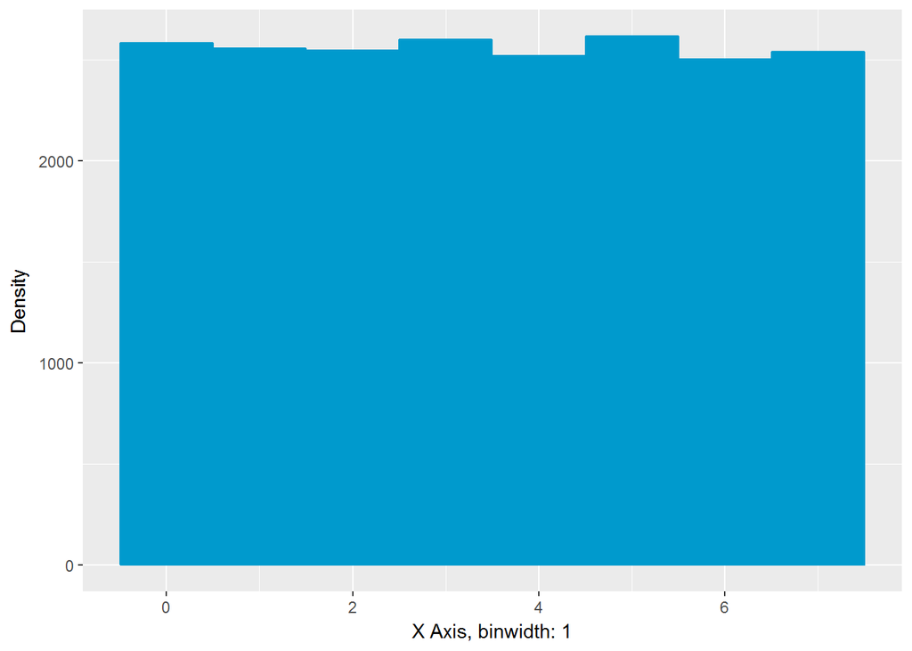

```r
ggplot(dataset, aes(x = numberofmonthunpaid)) +
  geom_histogram(stat = "bin", binwidth = 1, colour = "deepskyblue3", fill = "deepskyblue3") + labs(x = "X Axis, binwidth: 1", y = "Density")
```

```r
reg12 <- lm(churn ~ numberofmonthunpaid, data = dataset)
summary(reg12)
```

```
##
## Call:
## lm(formula = churn ~ numberofmonthunpaid, data = dataset)
##
## Residuals:
##      Min       1Q   Median       3Q      Max
## -0.09333 -0.09201 -0.09070 -0.08938  0.91127
##
## Coefficients:
##                      Estimate Std. Error t value Pr(>|t|)
## (Intercept)         0.0887269  0.0036647  24.211   <2e-16 ***
## numberofmonthunpaid 0.0006572  0.0008781   0.748    0.454
## ---
## Signif. codes:  0 '***' 0.001 '**' 0.01 '*' 0.05 '.' 0.1 ' ' 1
##
## Residual standard error: 0.2876 on 20466 degrees of freedom
## Multiple R-squared:  2.737e-05,  Adjusted R-squared:  -2.149e-05
## F-statistic: 0.5602 on 1 and 20466 DF,  p-value: 0.4542
```

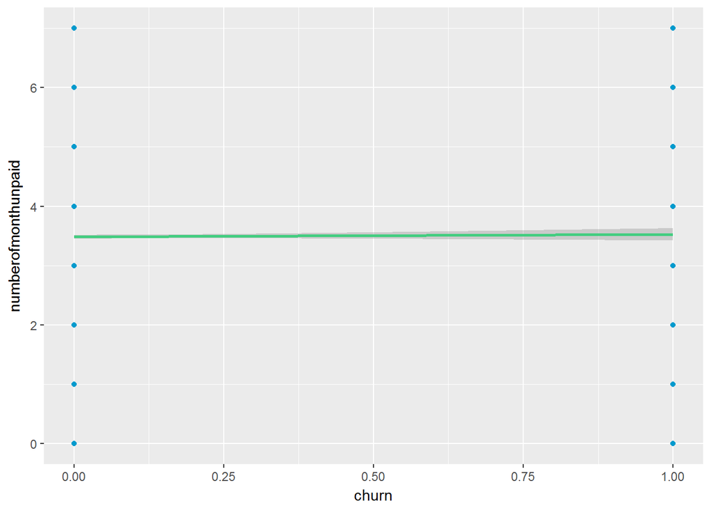

```r
ggplot(data = dataset, aes(x = churn, y = numberofmonthunpaid)) +
  geom_point(size = 1.5, colour = "deepskyblue3") +
  geom_smooth(method = "lm", colour = "seagreen3", se = T)
```

## Predictor: Number of Days when the Contract Equipment Plan is Expiring

Our dataset of contract expiry date is symmetrically distributed between 0 and 99 days, however, there is very small correlation between expiray date and churn.

```r
summary(dataset$numdayscontractequipmentplanexpiring)
```

```
##    Min. 1st Qu.  Median    Mean 3rd Qu.    Max.
##    0.00   24.00   49.00   49.37   74.00   99.00
```

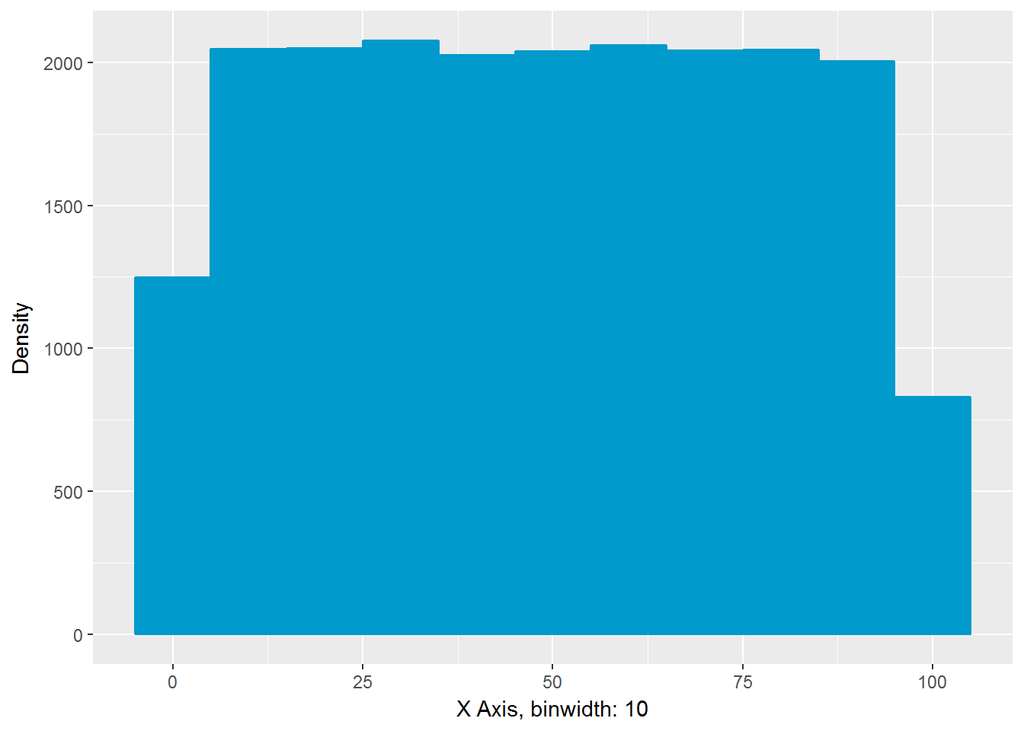

```r
ggplot(dataset, aes(x = numdayscontractequipmentplanexpiring)) +
  geom_histogram(stat = "bin", binwidth = 10, colour = "deepskyblue3", fill = "deepskyblue3") + labs(x = "X Axis, binwidth: 10", y = "Density")
```

```r
reg13 <- lm(churn ~ numdayscontractequipmentplanexpiring, data = dataset)
summary(reg13)
```

```
##
## Call:
## lm(formula = churn ~ numdayscontractequipmentplanexpiring, data = dataset)
##
## Residuals:
##      Min       1Q   Median       3Q      Max
## -0.09982 -0.09501 -0.09002 -0.08520  0.91783
##
## Coefficients:
##                                        Estimate Std. Error t value
## (Intercept)                           9.982e-02  3.982e-03   25.07
## numdayscontractequipmentplanexpiring -1.782e-04  6.962e-05   -2.56
##                                      Pr(>|t|)
## (Intercept)                            <2e-16 ***
## numdayscontractequipmentplanexpiring   0.0105 *
## ---
## Signif. codes:  0 '***' 0.001 '**' 0.01 '*' 0.05 '.' 0.1 ' ' 1
##
## Residual standard error: 0.2876 on 20466 degrees of freedom
## Multiple R-squared:  0.0003201,  Adjusted R-squared:  0.0002713
## F-statistic: 6.554 on 1 and 20466 DF,  p-value: 0.01047
```

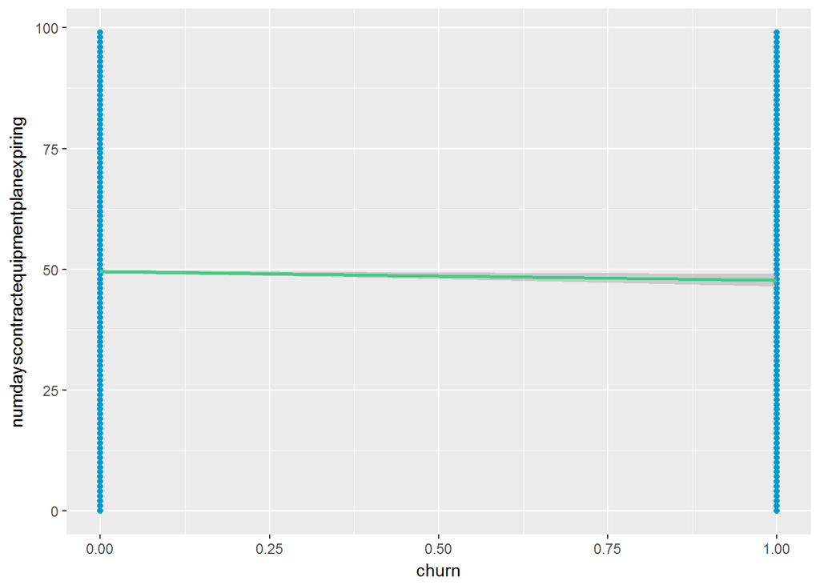

```r
ggplot(data = dataset, aes(x = churn, y = numdayscontractequipmentplanexpiring)) +
  geom_point(size = 1.5, colour = "deepskyblue3") +
  geom_smooth(method = "lm", colour = "seagreen3", se = T)
```

## Predictor: Occupation

In our dataset there’s an occupation categorization into people working in technology-related, non-technology related and other jobs. As strange as this classification is, we leave it as predictor as customers classified in the non-technology occupation are more likely to churn (with a statistical significance), which should end up as important factor.

```r
summary(dataset$occupation)
```

```
## Non-technology Related Job                     Others
##                       6189                       8189
##     Technology Related Job
##                       6090
```

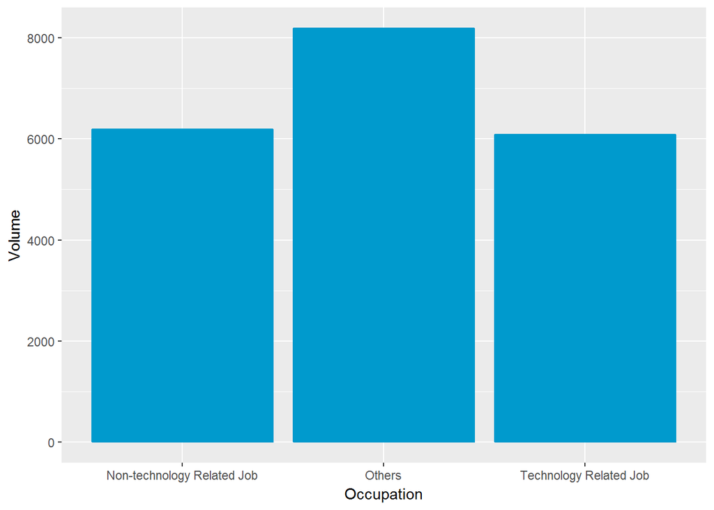

```r
ggplot(dataset, aes(occupation, ..count..)) +
  geom_bar(colour = "deepskyblue3", fill = "deepskyblue3") + labs(x = "Occupation", y = "Volume")
```

```r
reg14 <- lm(churn ~ occupation, data = dataset)
summary(reg14)
```

```
##
## Call:
## lm(formula = churn ~ occupation, data = dataset)
##
## Residuals:
##      Min       1Q   Median       3Q      Max
## -0.09872 -0.09872 -0.08878 -0.08621  0.91379
##
## Coefficients:
##                                   Estimate Std. Error t value Pr(>|t|)
## (Intercept)                       0.098724   0.003656  27.004   <2e-16 ***
## occupationOthers                 -0.009946   0.004844  -2.053   0.0401 *
## occupationTechnology Related Job -0.012517   0.005191  -2.411   0.0159 *
## ---
## Signif. codes:  0 '***' 0.001 '**' 0.01 '*' 0.05 '.' 0.1 ' ' 1
##
## Residual standard error: 0.2876 on 20465 degrees of freedom
## Multiple R-squared:  0.0003245,  Adjusted R-squared:  0.0002268
## F-statistic: 3.322 on 2 and 20465 DF,  p-value: 0.03611
```

## Predictor: Penalty to Switch

Penalty to switch moves between 0 and 499 USD, with a median of 249 USD - so quite significant amounts, but they don’t seem to correlate with with churn intent.

```r
summary(dataset$penaltytoswitch)
```

```
##    Min. 1st Qu.  Median    Mean 3rd Qu.    Max.
##     0.0   124.0   249.0   248.8   373.0   499.0
```

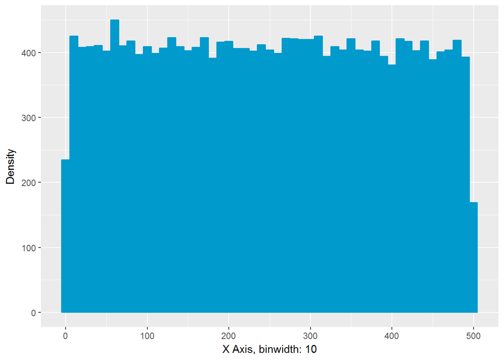

```r
ggplot(dataset, aes(x = penaltytoswitch)) +
  geom_histogram(stat = "bin", binwidth = 10, colour = "deepskyblue3", fill = "deepskyblue3") + labs(x = "X Axis, binwidth: 10", y = "Density")
```

```r
reg15 <- lm(churn ~ penaltytoswitch, data = dataset)
summary(reg15)
```

```
##
## Call:
## lm(formula = churn ~ penaltytoswitch, data = dataset)
##
## Residuals:
##      Min       1Q   Median       3Q      Max
## -0.09204 -0.09149 -0.09092 -0.09035  0.91000
##
## Coefficients:
##                   Estimate Std. Error t value Pr(>|t|)
## (Intercept)      9.204e-02  4.009e-03  22.960   <2e-16 ***
## penaltytoswitch -4.087e-06  1.394e-05  -0.293    0.769
## ---
## Signif. codes:  0 '***' 0.001 '**' 0.01 '*' 0.05 '.' 0.1 ' ' 1
##
## Residual standard error: 0.2877 on 20466 degrees of freedom
## Multiple R-squared:  4.201e-06,  Adjusted R-squared:  -4.466e-05
## F-statistic: 0.08598 on 1 and 20466 DF,  p-value: 0.7694
```

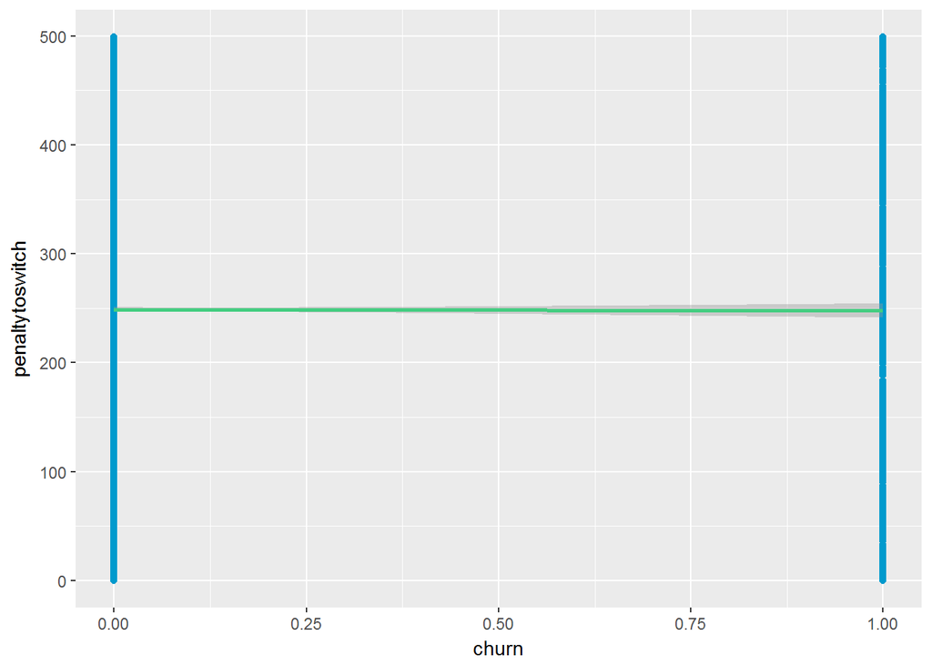

```r
ggplot(data = dataset, aes(x = churn, y = penaltytoswitch)) +
  geom_point(size = 1.5, colour = "deepskyblue3") +
  geom_smooth(method = "lm", colour = "seagreen3", se = T)
```

## Predictor: State

```r
summary(dataset$state)
```

```
##  AK  AL  AR  AZ  CA  CO  CT  DE  FL  GA  HI  IA  ID  IL  IN  KS  KY  LA
## 461 334 337 450 449 442 350 423 459 339 478 418 411 377 423 395 450 400
##  MA  MD  ME  MI  MN  MO  MS  MT  NC  ND  NE  NH  NJ  NM  NV  NY  OH  OK
## 398 469 361 388 451 377 398 442 360 427 371 455 377 390 397 468 435 372
##  OR  PA  RI  SC  SD  TN  TX  UT  VA  VT  WA  WI  WV  WY
## 394 448 376 404 427 356 437 425 407 373 444 440 351 454
```

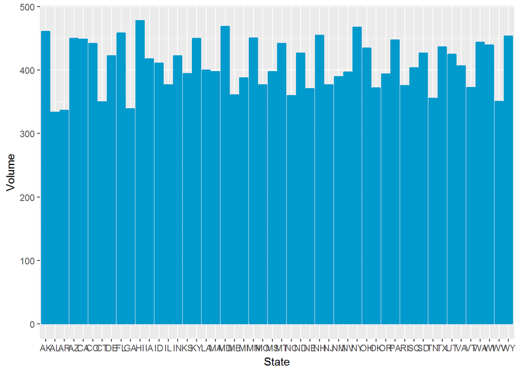

```r
ggplot(dataset, aes(state, ..count..)) +
  geom_bar(colour = "deepskyblue3", fill = "deepskyblue3") + labs(x = "State", y = "Volume")
```

```r
reg16 <- lm(churn ~ state, data = dataset)
summary(reg16)
```

```
##
## Call:
## lm(formula = churn ~ state, data = dataset)
##
## Residuals:
##      Min       1Q   Median       3Q      Max
## -0.15842 -0.10407 -0.08864 -0.07427  0.96515
##
## Coefficients:
##               Estimate Std. Error t value Pr(>|t|)
## (Intercept)  0.0802603  0.0133745   6.001 1.99e-09 ***
## stateAL     -0.0293621  0.0206342  -1.423  0.15476
## stateAR      0.0295320  0.0205808   1.435  0.15132
## stateAZ      0.0219619  0.0190296   1.154  0.24848
## stateCA      0.0600515  0.0190403   3.154  0.00161 **
## stateCO      0.0238121  0.0191165   1.246  0.21292
## stateCT      0.0054540  0.0203588   0.268  0.78878
## stateDE     -0.0022461  0.0193345  -0.116  0.90752
## stateFL     -0.0018289  0.0189349  -0.097  0.92305
## stateGA     -0.0035641  0.0205457  -0.173  0.86228
## stateHI      0.0138820  0.0187454   0.741  0.45897
## stateIA      0.0465340  0.0193947   2.399  0.01643 *
## stateID      0.0243626  0.0194811   1.251  0.21110
## stateIL     -0.0059897  0.0199401  -0.300  0.76389
## stateIN     -0.0046102  0.0193345  -0.238  0.81154
## stateKS      0.0083473  0.0196886   0.424  0.67160
## stateKY      0.0330730  0.0190296   1.738  0.08223 .
## stateLA     -0.0277603  0.0196222  -1.415  0.15716
## stateMA      0.0127045  0.0196486   0.647  0.51791
## stateMD     -0.0120300  0.0188335  -0.639  0.52299
## stateME      0.0166926  0.0201817   0.827  0.40818
## stateMI      0.0073686  0.0197840   0.372  0.70956
## stateMN     -0.0115242  0.0190189  -0.606  0.54457
## stateMO      0.0099254  0.0199401   0.498  0.61866
## stateMS      0.0026543  0.0196486   0.135  0.89254
## stateMT      0.0102374  0.0191165   0.536  0.59229
## stateNC      0.0225175  0.0201975   1.115  0.26492
## stateND      0.0274680  0.0192872   1.424  0.15442
## stateNE     -0.0317428  0.0200286  -1.585  0.11301
## stateNH      0.0142452  0.0189766   0.751  0.45286
```

[output cut: 11 more lines]

```
## stateTN     -0.0044176  0.0202611  -0.218  0.82740
## stateTX      0.0066962  0.0191723   0.349  0.72689
## stateUT      0.0256220  0.0193107   1.327  0.18458
## stateVA     -0.0065502  0.0195317  -0.335  0.73735
## stateVT     -0.0454078  0.0199989  -2.271  0.02319 *
## stateWA      0.0165865  0.0190945   0.869  0.38505
## stateWI      0.0083761  0.0191387   0.438  0.66164
## stateWV      0.0251528  0.0203423   1.236  0.21630
## stateWY      0.0144534  0.0189871   0.761  0.44654
## ---
## Signif. codes:  0 '***' 0.001 '**' 0.01 '*' 0.05 '.' 0.1 ' ' 1
##
## Residual standard error: 0.2872 on 20418 degrees of freedom
## Multiple R-squared:  0.00574,    Adjusted R-squared:  0.003354
## F-statistic: 2.406 on 49 and 20418 DF,  p-value: 1.405e-07
```

## Predictor: Total Minutes Used in Last Month

Total minutes used last month shows a symmetric distribution of minutes, from 0 to 499 with a median of 249 minutes. According to our dataset, it seems that there is no correlation between power-usage and churn.

```r
summary(dataset$totalminsusedinlastmonth)
```

```
##    Min. 1st Qu.  Median    Mean 3rd Qu.    Max.
##     0.0   126.0   249.0   249.7   374.0   499.0
```

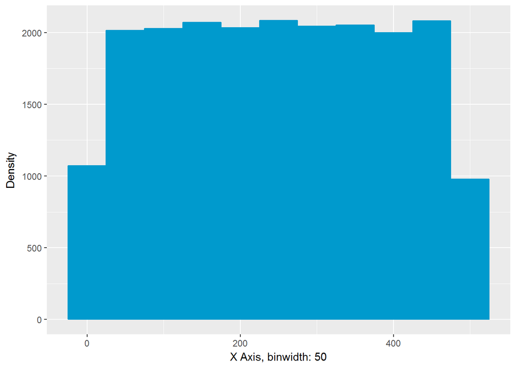

```r
ggplot(dataset, aes(x = totalminsusedinlastmonth)) +
  geom_histogram(stat = "bin", binwidth = 50, colour = "deepskyblue3", fill = "deepskyblue3") + labs(x = "X Axis, binwidth: 50", y = "Density")
```

```r
reg17 <- lm(churn ~ totalminsusedinlastmonth, data = dataset)
summary(reg17)
```

```
##
## Call:
## lm(formula = churn ~ totalminsusedinlastmonth, data = dataset)
##
## Residuals:
##      Min       1Q   Median       3Q      Max
## -0.09291 -0.09186 -0.09083 -0.08980  0.91087
##
## Coefficients:
##                           Estimate Std. Error t value Pr(>|t|)
## (Intercept)              8.913e-02  4.021e-03  22.166   <2e-16 ***
## totalminsusedinlastmonth 7.563e-06  1.394e-05   0.542    0.588
## ---
## Signif. codes:  0 '***' 0.001 '**' 0.01 '*' 0.05 '.' 0.1 ' ' 1
##
## Residual standard error: 0.2876 on 20466 degrees of freedom
## Multiple R-squared:  1.437e-05,  Adjusted R-squared:  -3.449e-05
## F-statistic: 0.2942 on 1 and 20466 DF,  p-value: 0.5876
```

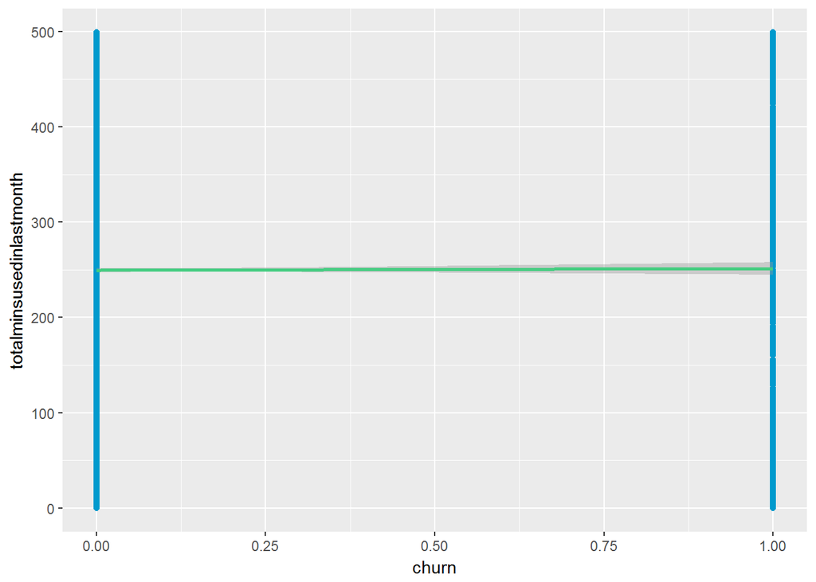

```r
ggplot(data = dataset, aes(x = churn, y = totalminsusedinlastmonth)) +
  geom_point(size = 1.5, colour = "deepskyblue3") +
  geom_smooth(method = "lm", colour = "seagreen3", se = T)
```

## Predictor: Unpaid Balance

```r
summary(dataset$unpaidbalance)
```

```
##    Min. 1st Qu.  Median    Mean 3rd Qu.    Max.
##     0.0    66.0   122.0   126.7   191.0   249.0
```

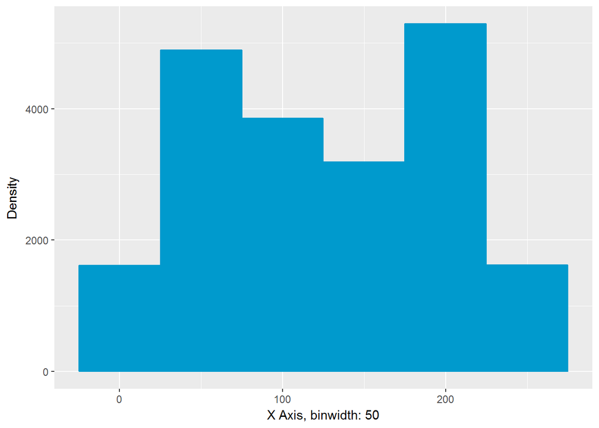

```r
ggplot(dataset, aes(x = unpaidbalance)) +
  geom_histogram(stat = "bin", binwidth = 50, colour = "deepskyblue3", fill = "deepskyblue3") + labs(x = "X Axis, binwidth: 50", y = "Density")
```

```r
reg18 <- lm(churn ~ unpaidbalance, data = dataset)
summary(reg18)
```

```
##
## Call:
## lm(formula = churn ~ unpaidbalance, data = dataset)
##
## Residuals:
##      Min       1Q   Median       3Q      Max
## -0.11477 -0.10254 -0.08720 -0.07672  0.93356
##
## Coefficients:
##                Estimate Std. Error t value Pr(>|t|)
## (Intercept)   6.644e-02  4.135e-03   16.07  < 2e-16 ***
## unpaidbalance 1.941e-04  2.854e-05    6.80 1.07e-11 ***
## ---
## Signif. codes:  0 '***' 0.001 '**' 0.01 '*' 0.05 '.' 0.1 ' ' 1
##
## Residual standard error: 0.2873 on 20466 degrees of freedom
## Multiple R-squared:  0.002254,   Adjusted R-squared:  0.002206
## F-statistic: 46.24 on 1 and 20466 DF,  p-value: 1.072e-11
```

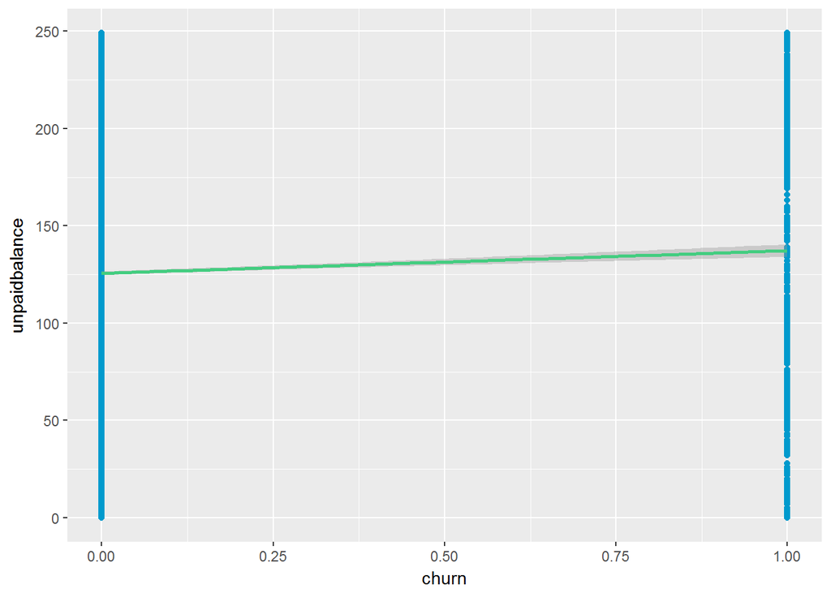

```r
ggplot(data = dataset, aes(x = churn, y = unpaidbalance)) +
  geom_point(size = 1.5, colour = "deepskyblue3") +
  geom_smooth(method = "lm", colour = "seagreen3", se = T)
```

## Predictor: Uses Internet Service

```r
summary(dataset$usesinternetservice)
```

```
##    No   Yes
## 19675   793
```

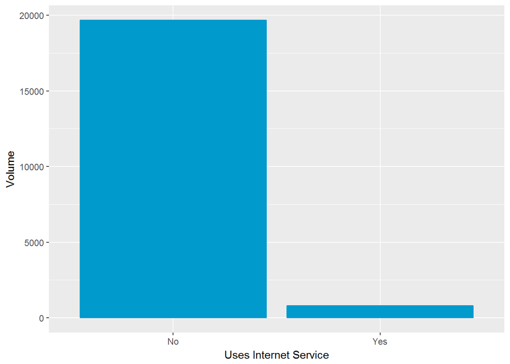

```r
ggplot(dataset, aes(usesinternetservice, ..count..)) +
  geom_bar(colour = "deepskyblue3", fill = "deepskyblue3") + labs(x = "Uses Internet Service", y = "Volume")
```

```r
reg19 <- lm(churn ~ usesinternetservice, data = dataset)
summary(reg19)
```

```
##
## Call:
## lm(formula = churn ~ usesinternetservice, data = dataset)
##
## Residuals:
##      Min       1Q   Median       3Q      Max
## -0.11349 -0.09011 -0.09011 -0.09011  0.90989
##
## Coefficients:
##                        Estimate Std. Error t value Pr(>|t|)
## (Intercept)             0.09011    0.00205  43.948   <2e-16 ***
## usesinternetserviceYes  0.02338    0.01042   2.244   0.0248 *
## ---
## Signif. codes:  0 '***' 0.001 '**' 0.01 '*' 0.05 '.' 0.1 ' ' 1
##
## Residual standard error: 0.2876 on 20466 degrees of freedom
## Multiple R-squared:  0.000246,   Adjusted R-squared:  0.0001972
## F-statistic: 5.036 on 1 and 20466 DF,  p-value: 0.02483
```

## Predictor: Uses Voice Service

```r
summary(dataset$usesvoiceservice)
```

```
##    No   Yes
## 18598  1870
```

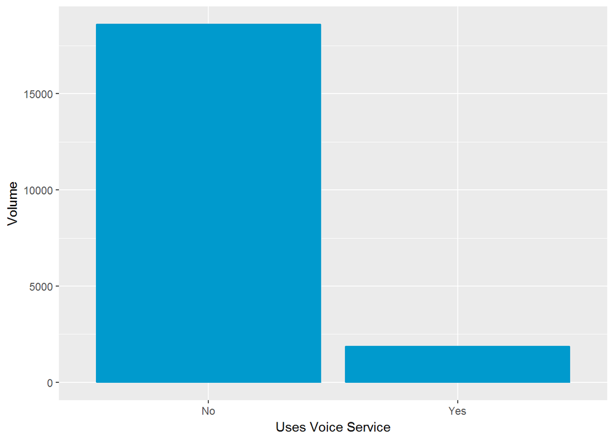

```r
ggplot(dataset, aes(usesvoiceservice, ..count..)) +
  geom_bar(colour = "deepskyblue3", fill = "deepskyblue3") + labs(x = "Uses Voice Service", y = "Volume")
```

```r
reg20 <- lm(churn ~ usesvoiceservice, data = dataset)
summary(reg20)
```

```
##
## Call:
## lm(formula = churn ~ usesvoiceservice, data = dataset)
##
## Residuals:
##     Min      1Q  Median      3Q     Max
## -0.0913 -0.0913 -0.0913 -0.0913  0.9118
##
## Coefficients:
##                      Estimate Std. Error t value Pr(>|t|)
## (Intercept)          0.091300   0.002109  43.285   <2e-16 ***
## usesvoiceserviceYes -0.003065   0.006978  -0.439    0.661
## ---
## Signif. codes:  0 '***' 0.001 '**' 0.01 '*' 0.05 '.' 0.1 ' ' 1
##
## Residual standard error: 0.2877 on 20466 degrees of freedom
## Multiple R-squared:  9.425e-06,  Adjusted R-squared:  -3.944e-05
## F-statistic: 0.1929 on 1 and 20466 DF,  p-value: 0.6605
```

## Predictor: Percentage Call Outside the Network

Half of the calls of our customers go outside of our network. Although the numbers don’t support statistical significance, it’s interesting to note that those making more calls outside the network tend to churn a bit less.

```r
summary(dataset$percentagecalloutsidenetwork)
```

```
##    Min. 1st Qu.  Median    Mean 3rd Qu.    Max.
##  0.0000  0.2500  0.5000  0.4965  0.7500  0.9900
```

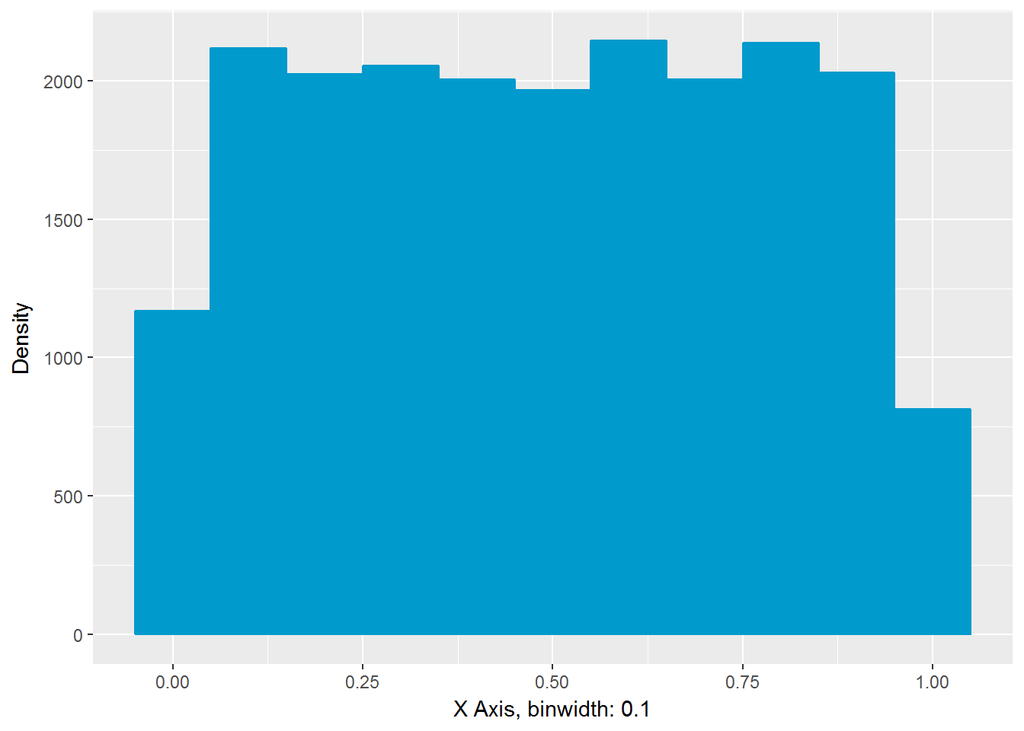

```r
ggplot(dataset, aes(x = percentagecalloutsidenetwork)) +
  geom_histogram(stat = "bin", binwidth = 0.1, colour = "deepskyblue3", fill = "deepskyblue3") + labs(x = "X Axis, binwidth: 0.1", y = "Density")
```

```r
reg21 <- lm(churn ~ percentagecalloutsidenetwork, data = dataset)
summary(reg21)
```

```
##
## Call:
## lm(formula = churn ~ percentagecalloutsidenetwork, data = dataset)
##
## Residuals:
##      Min       1Q   Median       3Q      Max
## -0.09741 -0.09394 -0.09033 -0.08686  0.91533
##
## Coefficients:
##                               Estimate Std. Error t value Pr(>|t|)
## (Intercept)                   0.097411   0.004005  24.324   <2e-16 ***
## percentagecalloutsidenetwork -0.012870   0.006976  -1.845    0.065 .
## ---
## Signif. codes:  0 '***' 0.001 '**' 0.01 '*' 0.05 '.' 0.1 ' ' 1
##
## Residual standard error: 0.2876 on 20466 degrees of freedom
## Multiple R-squared:  0.0001663,  Adjusted R-squared:  0.0001175
## F-statistic: 3.404 on 1 and 20466 DF,  p-value: 0.06505
```

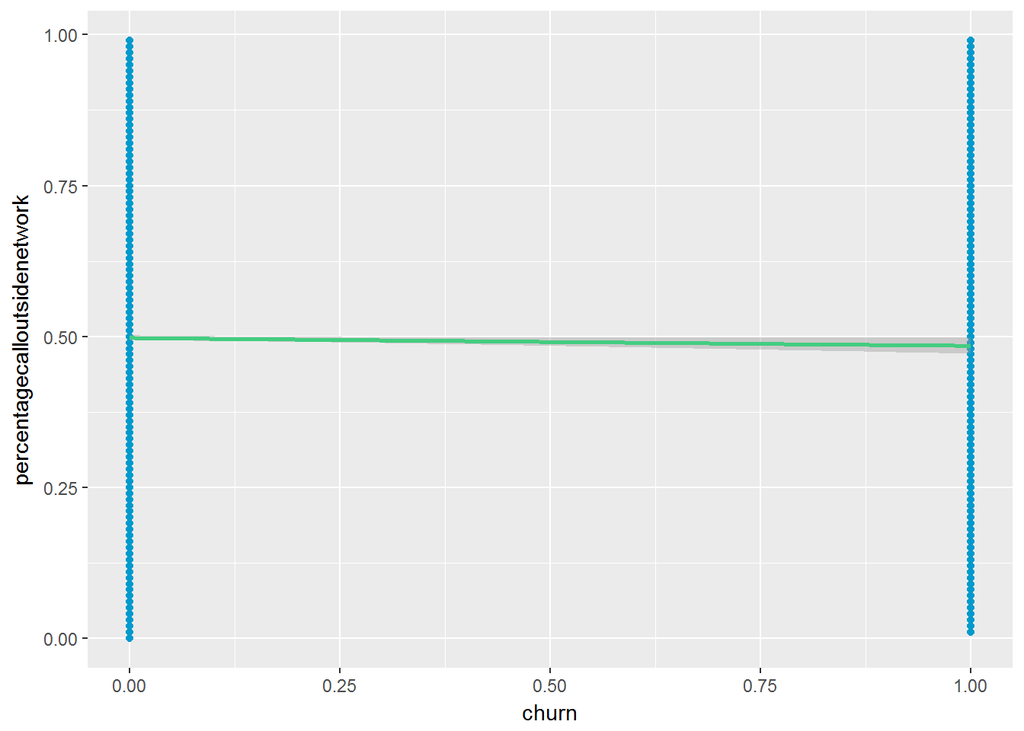

```r
ggplot(data = dataset, aes(x = churn, y = percentagecalloutsidenetwork)) +
  geom_point(size = 1.5, colour = "deepskyblue3") +
  geom_smooth(method = "lm", colour = "seagreen3", se = T)
```

## Predictor: Total Call Duration

The median of total call duration is 3365 minutes, with half of the observations between 2048 and 4786 minutes. The total call duration dataset is skewed to the right and will be truncated from 10001 minutes for the machine learning model.

```r
summary(dataset$totalcallduration)
```

```
##    Min. 1st Qu.  Median    Mean 3rd Qu.    Max.
##       0    2048    3365    3522    4786   16660
```

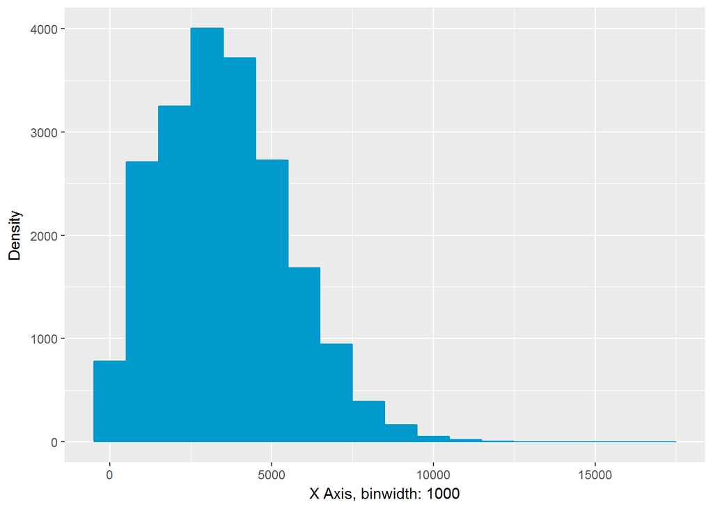

```r
ggplot(dataset, aes(x = totalcallduration)) +
  geom_histogram(stat = "bin", binwidth = 1000, colour = "deepskyblue3", fill = "deepskyblue3") + labs(x = "X Axis, binwidth: 1000", y = "Density")
```

```r
reg22 <- lm(churn ~ totalcallduration, data = dataset)
summary(reg22)
```

```
##
## Call:
## lm(formula = churn ~ totalcallduration, data = dataset)
##
## Residuals:
##      Min       1Q   Median       3Q      Max
## -0.09623 -0.09299 -0.09085 -0.08827  0.92056
##
## Coefficients:
##                     Estimate Std. Error t value Pr(>|t|)
## (Intercept)        9.623e-02  4.135e-03  23.274   <2e-16 ***
## totalcallduration -1.481e-06  1.026e-06  -1.443    0.149
## ---
## Signif. codes:  0 '***' 0.001 '**' 0.01 '*' 0.05 '.' 0.1 ' ' 1
##
## Residual standard error: 0.2876 on 20466 degrees of freedom
## Multiple R-squared:  0.0001017,  Adjusted R-squared:  5.289e-05
## F-statistic: 2.083 on 1 and 20466 DF,  p-value: 0.149
```

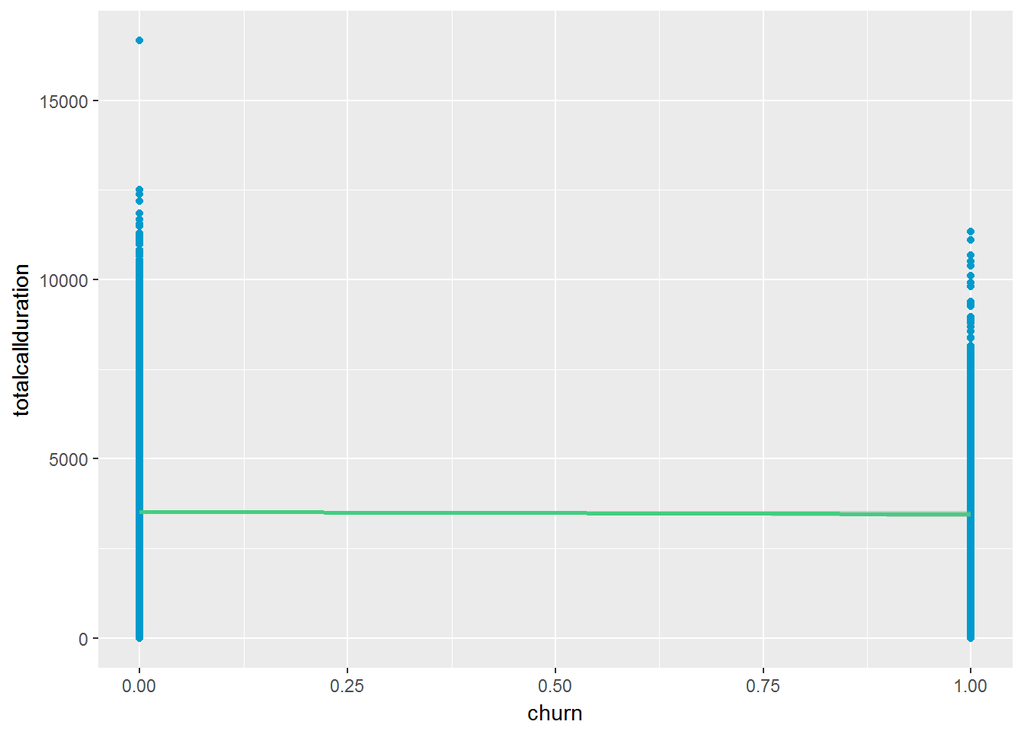

```r
ggplot(data = dataset, aes(x = churn, y = totalcallduration)) +
  geom_point(size = 1.5, colour = "deepskyblue3") +
  geom_smooth(method = "lm", colour = "seagreen3", se = T)
```

## Predictor: Average Call Duration

Average call durations show a nice symmetric standard distribution with a median of 721 very close to the mean of 721.5. However, it doesn’t have a significant effect on churn rate.

```r
summary(dataset$avgcallduration)
```

```
##    Min. 1st Qu.  Median    Mean 3rd Qu.    Max.
##     0.0   582.0   721.0   721.5   862.0  1439.0
```

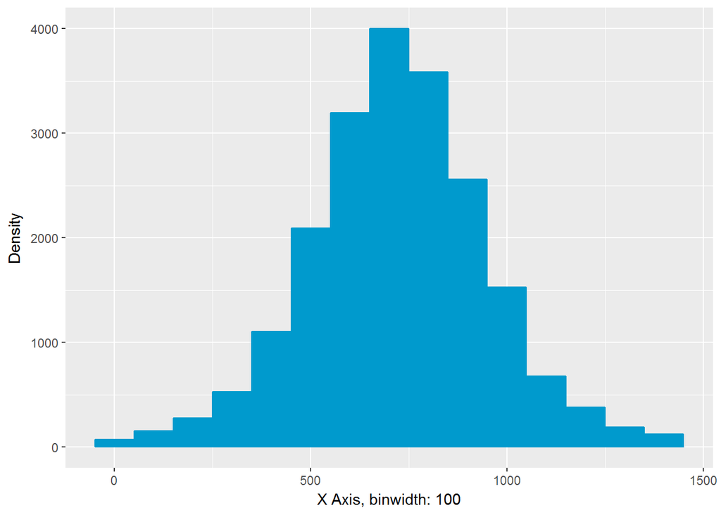

```r
ggplot(dataset, aes(x = avgcallduration)) +
  geom_histogram(stat = "bin", binwidth = 100, colour = "deepskyblue3", fill = "deepskyblue3") + labs(x = "X Axis, binwidth: 100", y = "Density")
```

```r
reg23 <- lm(churn ~ avgcallduration, data = dataset)
summary(reg23)
```

```
##
## Call:
## lm(formula = churn ~ avgcallduration, data = dataset)
##
## Residuals:
##      Min       1Q   Median       3Q      Max
## -0.09275 -0.09131 -0.09096 -0.09054  0.91068
##
## Coefficients:
##                   Estimate Std. Error t value Pr(>|t|)
## (Intercept)      9.275e-02  6.735e-03  13.770   <2e-16 ***
## avgcallduration -2.397e-06  8.909e-06  -0.269    0.788
## ---
## Signif. codes:  0 '***' 0.001 '**' 0.01 '*' 0.05 '.' 0.1 ' ' 1
##
## Residual standard error: 0.2877 on 20466 degrees of freedom
## Multiple R-squared:  3.537e-06,  Adjusted R-squared:  -4.532e-05
## F-statistic: 0.07239 on 1 and 20466 DF,  p-value: 0.7879
```

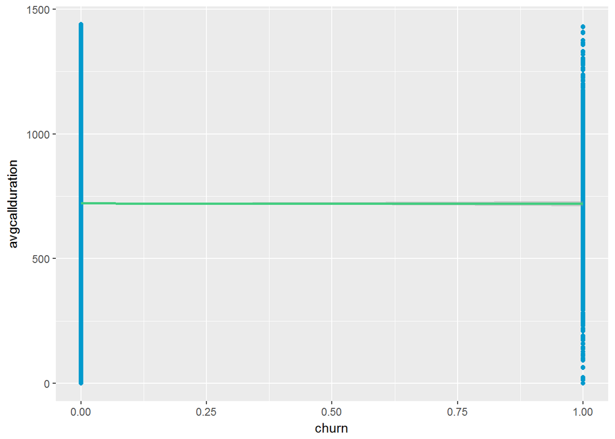

```r
ggplot(data = dataset, aes(x = churn, y = avgcallduration)) +
  geom_point(size = 1.5, colour = "deepskyblue3") +
  geom_smooth(method = "lm", colour = "seagreen3", se = T)
```

## Prepare Final Dataset

Preparing the final dataset with the following transformations:

- removing Customer Suspension variables
- removing No Additional Lines variables
- anonymizing dataset by removing Customer ID and Calling Number
- removing Year and Month referring to the data recording timeframe of the churn
- truncating Total Call Duration from 10001
- creating boolean variables from Education, Gender, Homeowner, Marital Status, Occupation, State, Uses Internet Service and Uses Voice Service

```r
finaldataset <- subset(dataset, dataset$totalcallduration < 10001)
finaldataset$customersuspended <- NULL
finaldataset$noadditionallines <- NULL
finaldataset$customerid <- NULL
finaldataset$customercallingnum <- NULL
finaldataset$month <- NULL
finaldataset$year <- NULL

lst <- strsplit(as.character(finaldataset$education),"-")
lvl <- unique(unlist(lst))
res <- data.frame(do.call(rbind,lapply(lst, function(x) table(factor(x, levels=lvl)))), stringsAsFactors=FALSE)
finaldataset <- cbind(finaldataset, res)
finaldataset$education <- NULL

lst <- strsplit(as.character(finaldataset$gender),"-")
lvl <- unique(unlist(lst))
res <- data.frame(do.call(rbind,lapply(lst, function(x) table(factor(x, levels=lvl)))), stringsAsFactors=FALSE)
finaldataset <- cbind(finaldataset, res)
finaldataset$gender <- NULL

lst <- strsplit(as.character(finaldataset$homeowner),"-")
lvl <- unique(unlist(lst))
res <- data.frame(do.call(rbind,lapply(lst, function(x) table(factor(x, levels=lvl)))), stringsAsFactors=FALSE)
colnames(res)[which(names(res) == "Yes")] <- "homeowner_yes"
colnames(res)[which(names(res) == "No")] <- "homeowner_no"
finaldataset <- cbind(finaldataset, res)
finaldataset$homeowner <- NULL

lst <- strsplit(as.character(finaldataset$maritalstatus),"-")
lvl <- unique(unlist(lst))
res <- data.frame(do.call(rbind,lapply(lst, function(x) table(factor(x, levels=lvl)))), stringsAsFactors=FALSE)
finaldataset <- cbind(finaldataset, res)
finaldataset$maritalstatus <- NULL

lst <- strsplit(as.character(finaldataset$occupation),"-")
lvl <- unique(unlist(lst))
res <- data.frame(do.call(rbind,lapply(lst, function(x) table(factor(x, levels=lvl)))), stringsAsFactors=FALSE)
finaldataset <- cbind(finaldataset, res)
finaldataset$occupation <- NULL

lst <- strsplit(as.character(finaldataset$state),"-")
lvl <- unique(unlist(lst))
res <- data.frame(do.call(rbind,lapply(lst, function(x) table(factor(x, levels=lvl)))), stringsAsFactors=FALSE)
finaldataset <- cbind(finaldataset, res)
finaldataset$state <- NULL

lst <- strsplit(as.character(finaldataset$usesinternetservice),"-")
lvl <- unique(unlist(lst))
res <- data.frame(do.call(rbind,lapply(lst, function(x) table(factor(x, levels=lvl)))), stringsAsFactors=FALSE)
colnames(res)[which(names(res) == "Yes")] <- "usesinternetservice_yes"
colnames(res)[which(names(res) == "No")] <- "usesinternetservice_no"
finaldataset <- cbind(finaldataset, res)
finaldataset$usesinternetservice <- NULL

lst <- strsplit(as.character(finaldataset$usesvoiceservice),"-")
lvl <- unique(unlist(lst))
res <- data.frame(do.call(rbind,lapply(lst, function(x) table(factor(x, levels=lvl)))), stringsAsFactors=FALSE)
colnames(res)[which(names(res) == "Yes")] <- "usesvoiceservice_yes"
colnames(res)[which(names(res) == "No")] <- "usesvoiceservice_no"
finaldataset <- cbind(finaldataset, res)
finaldataset$usesvoiceservice <- NULL
```

## Split Train/Test Datasets

We split our dataset into training, validation and test sets. We will keep our test set untouched until the selection of our final model.

The split will be the following:

- 50% for training
- 25% for validation
- 25% for testing

```r
set.seed(123)
N <- nrow(finaldataset)
idx_train <- sample(1:N,N/2)
idx_valid <- sample(base::setdiff(1:N, idx_train), N/4)
idx_test <- base::setdiff(base::setdiff(1:N, idx_train),idx_valid)
d_train <- finaldataset[idx_train,]
d_valid <- finaldataset[idx_valid,]
d_test  <- finaldataset[idx_test,]
```

## Modeling

We took the following aspects into account when choosing our model:

- business question that needs to be answered: we intend to build a classifier predicting whether a customer will churn or not
- volume and structure of the data: we are going to work with more than 20k observations and 29 different variables (some of them will be transformed into boolean variables)
- readiness of the modeler: our beginner level of modeling capability drives us towards algorithms which tend to perform well without too much tweaking

## Setup

We will use H2O as our machine learning engine and will use 3 types of random forest and 3 types of gradient boosting methods. Random forests and GBMs are top choices when it comes to situations cited above. We will also be able to do a simple grid search with 3 different hyperparameters that we can more easily understand (number of trees, maximum depth and learning rate).

We will use H2O as our machine learning engine and will use 3 types of random forest and 3 types of gradient boosting methods.

```r
library(h2o)
localH2O = h2o.init()
```

[output not shown]

```r
dx_train <- as.h2o(d_train)
dx_train$churn <- as.factor(dx_train$churn)
dx_valid <- as.h2o(d_valid)
dx_valid$churn <- as.factor(dx_valid$churn)
dx_test <- as.h2o(d_test)
dx_test$churn <- as.factor(dx_test$churn)
```

# Random forest choices:

- model 1: ntrees = 100, max_depth = 5,
- model 2: ntrees = 200, max_depth = 10,
- ntrees = 1000, max_depth = 15.

## Random forest 1

Training performance: 0.65, test performance: 0.66

```r
{
  md_rf <- h2o.randomForest(x = c(2:83),
                            y = "churn",
                            training_frame = dx_train,
                            mtries = -1,
                            ntrees = 100,
                            max_depth = 5,
                            nbins = 20)
}
md_rf
```

```
## Model Details:
## ==============
##
## H2OBinomialModel: drf
## Model ID:  DRF_model_R_1485967378443_1
## Model Summary:
##   number_of_trees number_of_internal_trees model_size_in_bytes min_depth
## 1             100                      100               36944         5
##   max_depth mean_depth min_leaves max_leaves mean_leaves
## 1         5    5.00000         14         32    24.39000
##
##
## H2OBinomialMetrics: drf
## ** Reported on training data. **
## ** Metrics reported on Out-Of-Bag training samples **
##
## MSE:  0.08016268
## RMSE:  0.2831302
## LogLoss:  0.2934832
## Mean Per-Class Error:  0.4027711
## AUC:  0.6621715
## Gini:  0.324343
##
## Confusion Matrix for F1-optimal threshold:
##           0    1    Error         Rate
## 0      7688 1601 0.172354   =1601/9289
## 1       580  336 0.633188     =580/916
## Totals 8268 1937 0.213719  =2181/10205
##
## Maximum Metrics: Maximum metrics at their respective thresholds
##                         metric threshold    value idx
## 1                       max f1  0.103472 0.235542 162
## 2                       max f2  0.086266 0.372851 253
## 3                 max f0point5  0.113882 0.217678 115
## 4                 max accuracy  0.163541 0.910926  22
## 5                max precision  0.260180 1.000000   0
## 6                   max recall  0.054288 1.000000 396
## 7              max specificity  0.260180 1.000000   0
## 8             max absolute_mcc  0.092625 0.147806 218
## 9   max min_per_class_accuracy  0.089668 0.618996 234
## 10 max mean_per_class_accuracy  0.092625 0.623145 218
##
## Gains/Lift Table: Extract with `h2o.gainsLift(<model>, <data>)` or `h2o.gainsLift(<model>, valid=<T/F>, xval=<T/F>)`
```

```r
h2o.auc(md_rf)
```

```
## [1] 0.6621715
```

```r
h2o.auc(h2o.performance(md_rf, dx_valid))
```

```
## [1] 0.6695774
```

## Random forest 2

Training performance: 0.77, test performance: 0.79

```r
{
  md_rf <- h2o.randomForest(x = c(2:83),
                            y = "churn",
                            training_frame = dx_train,
                            mtries = -1,
                            ntrees = 200,
                            max_depth = 10,
                            nbins = 20)
}
md_rf
```

```
## Model Details:
## ==============
##
## H2OBinomialModel: drf
## Model ID:  DRF_model_R_1485967378443_38
## Model Summary:
##   number_of_trees number_of_internal_trees model_size_in_bytes min_depth
## 1             200                      200              435264        10
##   max_depth mean_depth min_leaves max_leaves mean_leaves
## 1        10   10.00000         93        281   167.92500
##
##
## H2OBinomialMetrics: drf
## ** Reported on training data. **
## ** Metrics reported on Out-Of-Bag training samples **
##
## MSE:  0.07429159
## RMSE:  0.2725648
## LogLoss:  0.2679704
## Mean Per-Class Error:  0.3176288
## AUC:  0.7802385
## Gini:  0.560477
##
## Confusion Matrix for F1-optimal threshold:
##           0   1    Error        Rate
## 0      8854 435 0.046830   =435/9289
## 1       539 377 0.588428    =539/916
## Totals 9393 812 0.095443  =974/10205
##
## Maximum Metrics: Maximum metrics at their respective thresholds
##                         metric threshold    value idx
## 1                       max f1  0.137566 0.436343 139
## 2                       max f2  0.106135 0.471157 205
## 3                 max f0point5  0.183356 0.525915  83
## 4                 max accuracy  0.186099 0.925135  81
## 5                max precision  0.388800 1.000000   0
## 6                   max recall  0.040143 1.000000 389
## 7              max specificity  0.388800 1.000000   0
## 8             max absolute_mcc  0.160846 0.404412 105
## 9   max min_per_class_accuracy  0.095731 0.703057 231
## 10 max mean_per_class_accuracy  0.106135 0.713585 205
##
## Gains/Lift Table: Extract with `h2o.gainsLift(<model>, <data>)` or `h2o.gainsLift(<model>, valid=<T/F>, xval=<T/F>)`
```

```r
h2o.auc(md_rf)
```

```
## [1] 0.7802385
```

```r
h2o.auc(h2o.performance(md_rf, dx_valid))
```

```
## [1] 0.798628
```

## Random forest 3

Training performance: 0.84, test performance: 0.85. The random forest model performed very consistently from training to validation set, and with quite fast computation.

```r
{
  md_rf <- h2o.randomForest(x = c(2:83),
                            y = "churn",
                            training_frame = dx_train,
                            mtries = -1,
                            ntrees = 1000,
                            max_depth = 15,
                            nbins = 20)
}
md_rf
```

```
## Model Details:
## ==============
##
## H2OBinomialModel: drf
## Model ID:  DRF_model_R_1485967378443_103
## Model Summary:
##   number_of_trees number_of_internal_trees model_size_in_bytes min_depth
## 1            1000                     1000             5757995        15
##   max_depth mean_depth min_leaves max_leaves mean_leaves
## 1        15   15.00000        216        781   452.04900
##
##
## H2OBinomialMetrics: drf
## ** Reported on training data. **
## ** Metrics reported on Out-Of-Bag training samples **
##
## MSE:  0.06407377
## RMSE:  0.253128
## LogLoss:  0.234129
## Mean Per-Class Error:  0.2549748
## AUC:  0.8431838
## Gini:  0.6863675
##
## Confusion Matrix for F1-optimal threshold:
##           0   1    Error        Rate
## 0      9227  62 0.006675    =62/9289
## 1       461 455 0.503275    =461/916
## Totals 9688 517 0.051249  =523/10205
##
## Maximum Metrics: Maximum metrics at their respective thresholds
##                         metric threshold    value idx
## 1                       max f1  0.194036 0.635031 143
## 2                       max f2  0.131838 0.580691 199
## 3                 max f0point5  0.220855 0.770992 127
## 4                 max accuracy  0.194036 0.948751 143
## 5                max precision  0.549174 1.000000   0
## 6                   max recall  0.036964 1.000000 384
## 7              max specificity  0.549174 1.000000   0
## 8             max absolute_mcc  0.194036 0.638720 143
## 9   max min_per_class_accuracy  0.095155 0.750000 256
## 10 max mean_per_class_accuracy  0.128318 0.775823 203
##
## Gains/Lift Table: Extract with `h2o.gainsLift(<model>, <data>)` or `h2o.gainsLift(<model>, valid=<T/F>, xval=<T/F>)`
```

```r
h2o.auc(md_rf)
```

```
## [1] 0.8431838
```

```r
h2o.auc(h2o.performance(md_rf, dx_valid))
```

```
## [1] 0.8546098
```

# GBM choices:

- model 1: ntrees = 100, max_depth = 5, learn_rate: 0.01,
- model 2: ntrees = 200, max_depth = 10, learn_rate: 0.03,
- ntrees = 1000, max_depth = 15, learn_rate: 0.1.

## GBM 1

Training performance: 0.74, test performance: 0.63. We already can compare with our first interation of the random forest performing better and more consistent across the training and the validation set.

```r
{
  md_gbm <- h2o.gbm(x = c(2:83),
                    y = "churn",
                    training_frame = dx_train,
                    ntrees = 100,
                    max_depth = 5,
                    learn_rate = 0.01)
}
md_gbm
```

```
## Model Details:
## ==============
##
## H2OBinomialModel: gbm
## Model ID:  GBM_model_R_1485967378443_164
## Model Summary:
##   number_of_trees number_of_internal_trees model_size_in_bytes min_depth
## 1             100                      100               36077         5
##   max_depth mean_depth min_leaves max_leaves mean_leaves
## 1         5    5.00000         19         30    23.70000
##
##
## H2OBinomialMetrics: gbm
## ** Reported on training data. **
##
## MSE:  0.07659362
## RMSE:  0.2767555
## LogLoss:  0.2780153
## Mean Per-Class Error:  0.3292099
## AUC:  0.7428029
## Gini:  0.4856057
##
## Confusion Matrix for F1-optimal threshold:
##           0    1    Error         Rate
## 0      8578  711 0.076542    =711/9289
## 1       533  383 0.581878     =533/916
## Totals 9111 1094 0.121901  =1244/10205
##
## Maximum Metrics: Maximum metrics at their respective thresholds
##                         metric threshold    value idx
## 1                       max f1  0.122863 0.381095 157
## 2                       max f2  0.107174 0.416105 201
## 3                 max f0point5  0.158695 0.433429  94
## 4                 max accuracy  0.176026 0.918373  72
## 5                max precision  0.454643 1.000000   0
## 6                   max recall  0.060257 1.000000 380
## 7              max specificity  0.454643 1.000000   0
## 8             max absolute_mcc  0.133939 0.331934 131
## 9   max min_per_class_accuracy  0.090121 0.658297 257
## 10 max mean_per_class_accuracy  0.112313 0.674504 186
##
## Gains/Lift Table: Extract with `h2o.gainsLift(<model>, <data>)` or `h2o.gainsLift(<model>, valid=<T/F>, xval=<T/F>)`
```

```r
h2o.auc(md_gbm)
```

```
## [1] 0.7428029
```

```r
h2o.auc(h2o.performance(md_gbm, dx_valid))
```

```
## [1] 0.6366004
```

## GBM 2

Training performance: 0.99, test performance: 0.81. We suspect overfitting in the case of this GBM model and we run the third, even more complex model just for completeness.

```r
{
  md_gbm <- h2o.gbm(x = c(2:83),
                    y = "churn",
                    training_frame = dx_train,
                    ntrees = 200,
                    max_depth = 10,
                    learn_rate = 0.03)
}
md_gbm
```

```
## Model Details:
## ==============
##
## H2OBinomialModel: gbm
## Model ID:  GBM_model_R_1485967378443_234
## Model Summary:
##   number_of_trees number_of_internal_trees model_size_in_bytes min_depth
## 1             200                      200              326510        10
##   max_depth mean_depth min_leaves max_leaves mean_leaves
## 1        10   10.00000         54        188   124.64500
##
##
## H2OBinomialMetrics: gbm
## ** Reported on training data. **
##
## MSE:  0.02070946
## RMSE:  0.1439078
## LogLoss:  0.09280697
## Mean Per-Class Error:  0.0145151
## AUC:  0.9997977
## Gini:  0.9995955
##
## Confusion Matrix for F1-optimal threshold:
##           0   1    Error       Rate
## 0      9283   6 0.000646    =6/9289
## 1        26 890 0.028384    =26/916
## Totals 9309 896 0.003136  =32/10205
##
## Maximum Metrics: Maximum metrics at their respective thresholds
##                         metric threshold    value idx
## 1                       max f1  0.207042 0.982340 215
## 2                       max f2  0.150309 0.981814 232
## 3                 max f0point5  0.226598 0.990143 212
## 4                 max accuracy  0.210328 0.996864 214
## 5                max precision  0.916328 1.000000   0
## 6                   max recall  0.109085 1.000000 252
## 7              max specificity  0.916328 1.000000   0
## 8             max absolute_mcc  0.207042 0.980692 215
## 9   max min_per_class_accuracy  0.143679 0.992358 234
## 10 max mean_per_class_accuracy  0.143679 0.993003 234
##
## Gains/Lift Table: Extract with `h2o.gainsLift(<model>, <data>)` or `h2o.gainsLift(<model>, valid=<T/F>, xval=<T/F>)`
```

```r
h2o.auc(md_gbm)
```

```
## [1] 0.9997977
```

```r
h2o.auc(h2o.performance(md_gbm, dx_valid))
```

```
## [1] 0.8170377
```

## GBM 3

```r
{
  md_gbm <- h2o.gbm(x = c(2:83),
                    y = "churn",
                    training_frame = dx_train,
                    ntrees = 1000,
                    max_depth = 15,
                    learn_rate = 0.1)
}
md_gbm
```

```
## Model Details:
## ==============
##
## H2OBinomialModel: gbm
## Model ID:  GBM_model_R_1485967378443_288
## Model Summary:
##   number_of_trees number_of_internal_trees model_size_in_bytes min_depth
## 1            1000                     1000             3831706        15
##   max_depth mean_depth min_leaves max_leaves mean_leaves
## 1        15   15.00000        127        588   299.28900
##
##
## H2OBinomialMetrics: gbm
## ** Reported on training data. **
##
## MSE:  7.815745e-28
## RMSE:  2.795665e-14
## LogLoss:  1.233356e-14
## Mean Per-Class Error:  0
## AUC:  1
## Gini:  1
##
## Confusion Matrix for F1-optimal threshold:
##           0   1    Error      Rate
## 0      9289   0 0.000000   =0/9289
## 1         0 916 0.000000    =0/916
## Totals 9289 916 0.000000  =0/10205
##
## Maximum Metrics: Maximum metrics at their respective thresholds
##                         metric threshold    value idx
## 1                       max f1  1.000000 1.000000   0
## 2                       max f2  1.000000 1.000000   0
## 3                 max f0point5  1.000000 1.000000   0
## 4                 max accuracy  1.000000 1.000000   0
## 5                max precision  1.000000 1.000000   0
## 6                   max recall  1.000000 1.000000   0
## 7              max specificity  1.000000 1.000000   0
## 8             max absolute_mcc  1.000000 1.000000   0
## 9   max min_per_class_accuracy  1.000000 1.000000   0
## 10 max mean_per_class_accuracy  1.000000 1.000000   0
##
## Gains/Lift Table: Extract with `h2o.gainsLift(<model>, <data>)` or `h2o.gainsLift(<model>, valid=<T/F>, xval=<T/F>)`
```

```r
h2o.auc(md_gbm)
```

```
## [1] 1
```

```r
h2o.auc(h2o.performance(md_gbm, dx_valid))
```

```
## [1] 0.8557081
```

## Results

Model complexities and computing times grow from 1 to 3.

Random forest

1: Training performance: 0.65, validation performance: 0.66

2: Training performance: 0.77, validation performance: 0.79

3: Training performance: 0.84, validation performance: 0.85

GBM

1: Training performance: 0.74, validation performance: 0.63

2: Training performance: 0.99, validation performance: 0.81

3: Training performance: 1, validation performance: 0.85

## Analysis of the chosen model

We suspect that a high precision algorithm performs best as only 12 of the predictors showed some kind of statistically significant correlation from the available 29 of the dataset. Tiny correlations among the factors can be picked up by algorithms, which are able to strengthen weak classifiers to a strong one.

## Testing the chosen model

Chosen model: random forest 3

```r
{
  md_rf <- h2o.randomForest(x = c(2:83),
                            y = "churn",
                            training_frame = dx_train,
                            mtries = -1,
                            ntrees = 1000,
                            max_depth = 15,
                            nbins = 20)
}
md_rf
```

```
## Model Details:
## ==============
##
## H2OBinomialModel: drf
## Model ID:  DRF_model_R_1485967378443_344
## Model Summary:
##   number_of_trees number_of_internal_trees model_size_in_bytes min_depth
## 1            1000                     1000             5780399        15
##   max_depth mean_depth min_leaves max_leaves mean_leaves
## 1        15   15.00000        203        726   453.77400
##
##
## H2OBinomialMetrics: drf
## ** Reported on training data. **
## ** Metrics reported on Out-Of-Bag training samples **
##
## MSE:  0.06412767
## RMSE:  0.2532344
## LogLoss:  0.2340855
## Mean Per-Class Error:  0.2542834
## AUC:  0.8459302
## Gini:  0.6918605
##
## Confusion Matrix for F1-optimal threshold:
##           0   1    Error        Rate
## 0      9179 110 0.011842   =110/9289
## 1       455 461 0.496725    =455/916
## Totals 9634 571 0.055365  =565/10205
##
## Maximum Metrics: Maximum metrics at their respective thresholds
##                         metric threshold    value idx
## 1                       max f1  0.183573 0.620040 143
## 2                       max f2  0.140982 0.587298 181
## 3                 max f0point5  0.221400 0.766437 119
## 4                 max accuracy  0.210278 0.947771 125
## 5                max precision  0.542855 1.000000   0
## 6                   max recall  0.037993 1.000000 380
## 7              max specificity  0.542855 1.000000   0
## 8             max absolute_mcc  0.208898 0.628281 126
## 9   max min_per_class_accuracy  0.095512 0.754367 251
## 10 max mean_per_class_accuracy  0.140982 0.775427 181
##
## Gains/Lift Table: Extract with `h2o.gainsLift(<model>, <data>)` or `h2o.gainsLift(<model>, valid=<T/F>, xval=<T/F>)`
```

```r
h2o.auc(md_rf)
```

```
## [1] 0.8459302
```

```r
h2o.auc(h2o.performance(md_rf, dx_test))
```

```
## [1] 0.8409357
```

# End results

We test our chosen model with the test set, leading to an AUROC of 0.84.

# Business value

As stated earlier, tracking telecommunication companies customers’ churn rates is key to maintain and possibly grow revenues. Identifying churn intent and handling it before the event occurs increases chances to keep the customer.

- previously dividing customers into groups of lifetime value, then the model can trigger different level of retention actions (like offering added value services for free, adjusting the monthly billing)
- low lifetime value customers can even have customer care messages that don’t require additional cost but do prevent churn intent

Also, the model can be used for non-action analysis spotting possible causes of churn intent like:

- is monthly billing inequality too high for loyal customers bacause we don’t offer enough assistance to spot which package to choose, causing possible churn (building an upsell or cross-sell program)
- is the service level right for specific customers, as several times upsell can be an effective method to prevent churn
- prediction of customers we have to loose anyhow, as they represent lower value and offering them churn prevention at a cost wouldn’t be beneficial

We can tweak our model further in the future by:

- tweaking hyperparameters further and/or adding new ones
- trying additional algorithms like neural network
- going back to the business stakeholders to collect additional predictors
- revisiting the model after collection of future data and building new training set